# Predictive Analytics

**Note:**

1. This notebook presents the output of Gemini with little to no human assistance. Intervention is only introduced to ensure code is able to run and proceed to the next stage.
2. Boxes highlighted in yellow indicates warning. This indicates the step where we think the LLM produces a somewhat problematic output. Some minor modifications are then made to the LLM output to ensure the code proceeds to run.

```python
import pandas as pd
import numpy as np
from sklearn.model_selection import train_test_split
from sklearn.preprocessing import LabelEncoder

pd.set_option('display.max_columns', None)
pd.options.plotting.backend = 'matplotlib'
```

### Load Dataset

**Prompt:**

Here is the dataset hotel_reservation.csv

**Note:**

1. The above is the prompt for GPT for which we are able to upload the full dataset.
2. For Gemini and Claude, we upload the first 20 rows of data.

```python
data = pd.read_csv('../../data/raw/hotel_reservations.csv')
data
```

|  | Booking_ID | no_of_adults | no_of_children | no_of_weekend_nights | no_of_week_nights | type_of_meal_plan | required_car_parking_space | room_type_reserved | lead_time | arrival_year | arrival_month | arrival_date | market_segment_type | repeated_guest | no_of_previous_cancellations | no_of_previous_bookings_not_canceled | avg_price_per_room | no_of_special_requests | booking_status |
| --- | --- | --- | --- | --- | --- | --- | --- | --- | --- | --- | --- | --- | --- | --- | --- | --- | --- | --- | --- |
| 0 | INN00001 | 2 | 0 | 1 | 2 | Meal Plan 1 | 0 | Room_Type 1 | 224 | 2017 | 10 | 2 | Offline | 0 | 0 | 0 | 65.00 | 0 | Not_Canceled |
| 1 | INN00002 | 2 | 0 | 2 | 3 | Not Selected | 0 | Room_Type 1 | 5 | 2018 | 11 | 6 | Online | 0 | 0 | 0 | 106.68 | 1 | Not_Canceled |
| 2 | INN00003 | 1 | 0 | 2 | 1 | Meal Plan 1 | 0 | Room_Type 1 | 1 | 2018 | 2 | 28 | Online | 0 | 0 | 0 | 60.00 | 0 | Canceled |
| 3 | INN00004 | 2 | 0 | 0 | 2 | Meal Plan 1 | 0 | Room_Type 1 | 211 | 2018 | 5 | 20 | Online | 0 | 0 | 0 | 100.00 | 0 | Canceled |
| 4 | INN00005 | 2 | 0 | 1 | 1 | Not Selected | 0 | Room_Type 1 | 48 | 2018 | 4 | 11 | Online | 0 | 0 | 0 | 94.50 | 0 | Canceled |
| ... | ... | ... | ... | ... | ... | ... | ... | ... | ... | ... | ... | ... | ... | ... | ... | ... | ... | ... | ... |
| 36270 | INN36271 | 3 | 0 | 2 | 6 | Meal Plan 1 | 0 | Room_Type 4 | 85 | 2018 | 8 | 3 | Online | 0 | 0 | 0 | 167.80 | 1 | Not_Canceled |
| 36271 | INN36272 | 2 | 0 | 1 | 3 | Meal Plan 1 | 0 | Room_Type 1 | 228 | 2018 | 10 | 17 | Online | 0 | 0 | 0 | 90.95 | 2 | Canceled |
| 36272 | INN36273 | 2 | 0 | 2 | 6 | Meal Plan 1 | 0 | Room_Type 1 | 148 | 2018 | 7 | 1 | Online | 0 | 0 | 0 | 98.39 | 2 | Not_Canceled |
| 36273 | INN36274 | 2 | 0 | 0 | 3 | Not Selected | 0 | Room_Type 1 | 63 | 2018 | 4 | 21 | Online | 0 | 0 | 0 | 94.50 | 0 | Canceled |
| 36274 | INN36275 | 2 | 0 | 1 | 2 | Meal Plan 1 | 0 | Room_Type 1 | 207 | 2018 | 12 | 30 | Offline | 0 | 0 | 0 | 161.67 | 0 | Not_Canceled |

36275 rows × 19 columns

**Prompt:**

Before we proceed, let me share the metadata for the dataset. The file contains the different attributes of customers' reservation details. The detailed data dictionary is given below. The goal is to build a classification model with the target variable being booking_status.

#### Dataset Source:

https://www.kaggle.com/datasets/ahsan81/hotel-reservations-classification-dataset

#### DBA4714 Deep Learning and Generative AI in Business

Revenue Management in Hotel Reservations

#### Problem Statement

The online hotel reservation channels have dramatically changed booking possibilities and customers’ behavior. A significant number of hotel reservations are called-off due to cancellations or no-shows. The typical reasons for cancellations include change of plans, scheduling conflicts, etc. This is often made easier by the option to do so free of charge or preferably at a low cost which is beneficial to hotel guests but it is a less desirable and possibly revenue-diminishing factor for hotels to deal with.

The file contains the different attributes of customers' reservation details. The detailed data dictionary is given below.

#### Train data:

| No. | Features | Description |
| --- | --- | --- |
| 1. | Booking_ID | Unique identifier of each booking |
| 2. | no_of_adults | Number of adults |
| 3. | no_of_children | Number of Children |
| 4. | no_of_weekend_nights | Number of weekend nights (Saturday or Sunday) the guest stayed or booked to stay at the hotel |
| 5. | no_of_week_nights | Number of week nights (Monday to Friday) the guest stayed or booked to stay at the hotel |
| 6. | type_of_meal_plan | Type of meal plan booked by the customer |
| 7. | required_car_parking_space | Does the customer require a car parking space? (0 - No, 1- Yes) |
| 8. | room_type_reserved | Type of room reserved by the customer. The values are ciphered (encoded) by INN Hotels. |
| 9. | lead_time | Number of days between the date of booking and the arrival date |
| 10. | arrival_year | Year of arrival date |
| 11. | arrival_month | Month of arrival date |
| 12. | arrival_date | Date of the month |
| 13. | market_segment_type | Market segment designation |
| 14. | repeated_guest | Is the customer a repeated guest? (0 - No, 1- Yes) |
| 15. | no_of_previous_cancellations | Number of previous bookings that were canceled by the customer prior to the current bookinge |
| 16. | no_of_previous_bookings_not_canceled | Number of previous bookings not canceled by the customer prior to the current booking |
| 17. | avg_price_per_room | Average price per day of the reservation; prices of the rooms are dynamic. (in euros) |
| 18. | no_of_special_requests | Total number of special requests made by the customer (e.g. high floor, view from the room, etc) |
| 19. | booking_status | Flag indicating if the booking was canceled or not |

**Prompt:**

There are faulty dates 29 February 2018 in the dataset. Help me drop these rows.

**Note:**

1. The LLM is unable to point out this data error as only 20 rows of data are provided. Hence, it assumes correct and provides no further validation.
2. This errors out at the later stage of the model building, in particular when dealing with datetime.
3. We iterate a few times and pick up this data error manually through prior experience in data cleaning. Then, we explicitly prompt the LLM to remove observations with this error.

```python
# Identify rows with the faulty date
error_mask = (data['arrival_month'] == 2) & (data['arrival_date'] == 29) & (data['arrival_year'] == 2018)

# Drop the rows with errors
clean_data = data[~error_mask]

# Print a message to confirm the removal
print(f"Removed {error_mask.sum()} rows with invalid dates.")
```

```
Removed 37 rows with invalid dates.
```

**Prompt:**

Perform train test split on my hotel data with test size 0.2 and stratify the target.

```python
# ... (Load your cleaned hotel data)
data = clean_data

# Separate features (X) and target variable (y)
X = data.drop('booking_status', axis=1)
y = data['booking_status']

# Perform the stratified split
X_train, X_test, y_train, y_test = train_test_split(X, y, test_size=0.2, random_state=42, stratify=y)
```

**Note:**

1. The LLM does not bother with the target especially at the first iteration. It focuses mainly on the transformation of features. While this is alright at this stage, we still need to encode our target later on. For convenience, we have manually encode the target early in the process.

```python
label_encoder = LabelEncoder()
y_train = (pd
           .DataFrame(label_encoder.fit_transform(y_train),
                      columns=['booking_status'])
           .astype({'booking_status': 'int8'})
           )

y_test = (pd
          .DataFrame(label_encoder.transform(y_test),
                     columns=['booking_status'])
          .astype({'booking_status': 'int8'})
          )

#  Optional: Check the class distribution in the train and test sets
print("Train set 'booking_status' distribution:\n", y_train.value_counts(normalize=True))
print("Test set 'booking_status' distribution:\n", y_test.value_counts(normalize=True))
```

```
Train set 'booking_status' distribution:
 booking_status
1                 0.672232
0                 0.327768
Name: proportion, dtype: float64
Test set 'booking_status' distribution:
 booking_status
1                 0.672185
0                 0.327815
Name: proportion, dtype: float64
```

**Prompt:**

Now I would like you to start doing feature engineering on the dataset.

Recommend new feature creation as part of the feature engineering process.

**Note:**

1. Even after running the train test split above, the LLM continues to use `data` instead of the training set. While this would still work, it would introduces data leakage, which is a fatal error and should be avoided at all cost.
2. In general, the LLM also tends to skip the needed transformation process for the test set.
3. While the LLMs are able to generate some interesting new features to enrich the feature space, we prompt the LLM further to obtain additional features we can manually think off based on our creativity.

**Further iteration:**

Sure, apart from your recommended feature, can you also create these features below?

1. `date_combined` in the following format (2017-10-02)
2. `lead_time_category` (i.e. < 90, 'Within 3 months', < 180, 'Within 6 months', > 180 'Beyond 6 months')
3. `total_people`
4. `is_alone`
5. `Total_nights_stay`
6. Indicator / flag to denote lead_time=0, name this feature as `walk_in`. For walk in case, denote as 1, else 0.
7. Indicator / flag to denote avg_price_per_room=0, name this feature as `promotional_offer`. For promotional offer case, denote as 1, else 0.
8. Extract out datetime features from date_combined such as `quarter`, `is_weekend_arrival`, `week of year`, etc.
9. Drop the date_combined after extraction of features from the datetime.

```python
# 1. Combining date features
X_train['date_combined'] = X_train['arrival_year'].astype(str) + '-' + X_train['arrival_month'].astype(str).str.zfill(2) + '-' + X_train['arrival_date'].astype(str).str.zfill(2)
X_test['date_combined'] = X_test['arrival_year'].astype(str) + '-' + X_test['arrival_month'].astype(str).str.zfill(2) + '-' + X_test['arrival_date'].astype(str).str.zfill(2)

# 2. Lead time categories
conditions = [
    X_train['lead_time'] < 90,
    (X_train['lead_time'] >= 90) & (X_train['lead_time'] < 180),
    X_train['lead_time'] >= 180
]
choices = ['Within 3 months', 'Within 6 months', 'Beyond 6 months']
X_train['lead_time_category'] = np.select(conditions, choices)
conditions = [
    X_test['lead_time'] < 90,
    (X_test['lead_time'] >= 90) & (X_test['lead_time'] < 180),
    X_test['lead_time'] >= 180
]
X_test['lead_time_category'] = np.select(conditions, choices)

# 3. total_people
X_train['total_people'] = X_train['no_of_adults'] + X_train['no_of_children']
X_test['total_people'] = X_test['no_of_adults'] + X_test['no_of_children']

# 4. is_alone
X_train['is_alone'] = (X_train['total_people'] == 1).astype(int)
X_test['is_alone'] = (X_test['total_people'] == 1).astype(int)

# 5. Total_nights_stay
X_train['total_nights_stay'] = X_train['no_of_weekend_nights'] + X_train['no_of_week_nights']
X_test['total_nights_stay'] = X_test['no_of_weekend_nights'] + X_test['no_of_week_nights']

# 6. walk_in indicator
X_train['walk_in'] = (X_train['lead_time'] == 0).astype(int)
X_test['walk_in'] = (X_test['lead_time'] == 0).astype(int)

# 7. promotional_offer indicator
X_train['promotional_offer'] = (X_train['avg_price_per_room'] == 0).astype(int)
X_test['promotional_offer'] = (X_test['avg_price_per_room'] == 0).astype(int)

# 8. Extract datetime features & drop 'date_combined'
X_train['arrival_weekday'] = pd.to_datetime(X_train['date_combined']).dt.day_name()
X_train['arrival_quarter'] = pd.to_datetime(X_train['date_combined']).dt.quarter
X_train['is_weekend_arrival'] = X_train['arrival_weekday'].isin(['Friday', 'Saturday', 'Sunday']).astype(int)
X_train['week_of_year'] = pd.to_datetime(X_train['date_combined']).dt.isocalendar().week
X_train.drop('date_combined', axis=1, inplace=True)

X_test['arrival_weekday'] = pd.to_datetime(X_test['date_combined']).dt.day_name()
X_test['arrival_quarter'] = pd.to_datetime(X_test['date_combined']).dt.quarter
X_test['is_weekend_arrival'] = X_test['arrival_weekday'].isin(['Friday', 'Saturday', 'Sunday']).astype(int)
X_test['week_of_year'] = pd.to_datetime(X_test['date_combined']).dt.isocalendar().week
X_test.drop('date_combined', axis=1, inplace=True)
```

```python
X_train
```

|  | Booking_ID | no_of_adults | no_of_children | no_of_weekend_nights | no_of_week_nights | type_of_meal_plan | required_car_parking_space | room_type_reserved | lead_time | arrival_year | arrival_month | arrival_date | market_segment_type | repeated_guest | no_of_previous_cancellations | no_of_previous_bookings_not_canceled | avg_price_per_room | no_of_special_requests | lead_time_category | total_people | is_alone | total_nights_stay | walk_in | promotional_offer | arrival_weekday | arrival_quarter | is_weekend_arrival | week_of_year |
| --- | --- | --- | --- | --- | --- | --- | --- | --- | --- | --- | --- | --- | --- | --- | --- | --- | --- | --- | --- | --- | --- | --- | --- | --- | --- | --- | --- | --- |
| 10409 | INN10410 | 2 | 0 | 0 | 2 | Not Selected | 0 | Room_Type 1 | 68 | 2018 | 3 | 11 | Online | 0 | 0 | 0 | 67.50 | 1 | Within 3 months | 2 | 0 | 2 | 0 | 0 | Sunday | 1 | 1 | 10 |
| 6307 | INN06308 | 2 | 1 | 0 | 3 | Meal Plan 1 | 0 | Room_Type 1 | 149 | 2018 | 7 | 20 | Online | 0 | 0 | 0 | 127.50 | 0 | Within 6 months | 3 | 0 | 3 | 0 | 0 | Friday | 3 | 1 | 29 |
| 19004 | INN19005 | 2 | 0 | 0 | 3 | Meal Plan 1 | 0 | Room_Type 1 | 72 | 2018 | 3 | 31 | Online | 0 | 0 | 0 | 67.22 | 0 | Within 3 months | 2 | 0 | 3 | 0 | 0 | Saturday | 1 | 1 | 13 |
| 9609 | INN09610 | 2 | 0 | 0 | 3 | Meal Plan 1 | 0 | Room_Type 1 | 259 | 2018 | 5 | 5 | Offline | 0 | 0 | 0 | 90.00 | 0 | Beyond 6 months | 2 | 0 | 3 | 0 | 0 | Saturday | 2 | 1 | 18 |
| 32308 | INN32309 | 2 | 0 | 2 | 0 | Meal Plan 1 | 1 | Room_Type 1 | 47 | 2017 | 12 | 6 | Online | 0 | 0 | 0 | 115.20 | 1 | Within 3 months | 2 | 0 | 2 | 0 | 0 | Wednesday | 4 | 0 | 49 |
| ... | ... | ... | ... | ... | ... | ... | ... | ... | ... | ... | ... | ... | ... | ... | ... | ... | ... | ... | ... | ... | ... | ... | ... | ... | ... | ... | ... | ... |
| 18283 | INN18284 | 1 | 0 | 0 | 1 | Not Selected | 0 | Room_Type 1 | 0 | 2018 | 8 | 20 | Online | 0 | 0 | 0 | 92.17 | 0 | Within 3 months | 1 | 1 | 1 | 1 | 0 | Monday | 3 | 0 | 34 |
| 7308 | INN07309 | 2 | 0 | 0 | 1 | Not Selected | 0 | Room_Type 1 | 143 | 2018 | 8 | 20 | Online | 0 | 0 | 0 | 94.50 | 0 | Within 6 months | 2 | 0 | 1 | 0 | 0 | Monday | 3 | 0 | 34 |
| 22902 | INN22903 | 1 | 0 | 3 | 7 | Meal Plan 1 | 0 | Room_Type 1 | 29 | 2018 | 4 | 15 | Online | 0 | 0 | 0 | 99.49 | 1 | Within 3 months | 1 | 1 | 10 | 0 | 0 | Sunday | 2 | 1 | 15 |
| 20224 | INN20225 | 2 | 1 | 1 | 3 | Meal Plan 1 | 0 | Room_Type 1 | 83 | 2018 | 8 | 1 | Online | 0 | 0 | 0 | 135.90 | 1 | Within 3 months | 3 | 0 | 4 | 0 | 0 | Wednesday | 3 | 0 | 31 |
| 5622 | INN05623 | 3 | 0 | 0 | 2 | Meal Plan 1 | 0 | Room_Type 4 | 9 | 2018 | 2 | 12 | Online | 0 | 0 | 0 | 139.00 | 1 | Within 3 months | 3 | 0 | 2 | 0 | 0 | Monday | 1 | 0 | 7 |

28990 rows × 28 columns

```python
X_test
```

|  | Booking_ID | no_of_adults | no_of_children | no_of_weekend_nights | no_of_week_nights | type_of_meal_plan | required_car_parking_space | room_type_reserved | lead_time | arrival_year | arrival_month | arrival_date | market_segment_type | repeated_guest | no_of_previous_cancellations | no_of_previous_bookings_not_canceled | avg_price_per_room | no_of_special_requests | lead_time_category | total_people | is_alone | total_nights_stay | walk_in | promotional_offer | arrival_weekday | arrival_quarter | is_weekend_arrival | week_of_year |
| --- | --- | --- | --- | --- | --- | --- | --- | --- | --- | --- | --- | --- | --- | --- | --- | --- | --- | --- | --- | --- | --- | --- | --- | --- | --- | --- | --- | --- |
| 31719 | INN31720 | 2 | 1 | 2 | 4 | Meal Plan 1 | 0 | Room_Type 1 | 132 | 2018 | 7 | 14 | Online | 0 | 0 | 0 | 114.75 | 0 | Within 6 months | 3 | 0 | 6 | 0 | 0 | Saturday | 3 | 1 | 28 |
| 22776 | INN22777 | 2 | 0 | 2 | 5 | Meal Plan 2 | 0 | Room_Type 1 | 3 | 2017 | 9 | 14 | Offline | 0 | 0 | 0 | 90.00 | 0 | Within 3 months | 2 | 0 | 7 | 0 | 0 | Thursday | 3 | 0 | 37 |
| 15869 | INN15870 | 3 | 0 | 2 | 2 | Meal Plan 1 | 0 | Room_Type 4 | 10 | 2018 | 4 | 29 | Online | 0 | 0 | 0 | 172.00 | 2 | Within 3 months | 3 | 0 | 4 | 0 | 0 | Sunday | 2 | 1 | 17 |
| 11331 | INN11332 | 2 | 0 | 1 | 1 | Meal Plan 1 | 0 | Room_Type 5 | 28 | 2018 | 10 | 8 | Online | 0 | 0 | 0 | 171.87 | 0 | Within 3 months | 2 | 0 | 2 | 0 | 0 | Monday | 4 | 0 | 41 |
| 13639 | INN13640 | 1 | 0 | 2 | 5 | Meal Plan 1 | 0 | Room_Type 1 | 7 | 2018 | 11 | 2 | Corporate | 1 | 0 | 2 | 65.00 | 1 | Within 3 months | 1 | 1 | 7 | 0 | 0 | Friday | 4 | 1 | 44 |
| ... | ... | ... | ... | ... | ... | ... | ... | ... | ... | ... | ... | ... | ... | ... | ... | ... | ... | ... | ... | ... | ... | ... | ... | ... | ... | ... | ... | ... |
| 7261 | INN07262 | 1 | 0 | 1 | 2 | Meal Plan 1 | 0 | Room_Type 4 | 3 | 2018 | 10 | 7 | Aviation | 0 | 0 | 0 | 110.00 | 0 | Within 3 months | 1 | 1 | 3 | 0 | 0 | Sunday | 4 | 1 | 40 |
| 395 | INN00396 | 2 | 1 | 2 | 3 | Meal Plan 1 | 0 | Room_Type 1 | 25 | 2018 | 7 | 23 | Online | 0 | 0 | 0 | 152.10 | 1 | Within 3 months | 3 | 0 | 5 | 0 | 0 | Monday | 3 | 0 | 30 |
| 18846 | INN18847 | 1 | 0 | 0 | 2 | Meal Plan 1 | 0 | Room_Type 4 | 17 | 2018 | 3 | 9 | Corporate | 0 | 0 | 0 | 75.00 | 0 | Within 3 months | 1 | 1 | 2 | 0 | 0 | Friday | 1 | 1 | 10 |
| 22540 | INN22541 | 3 | 0 | 1 | 2 | Meal Plan 2 | 0 | Room_Type 4 | 109 | 2018 | 10 | 28 | Online | 0 | 0 | 0 | 174.60 | 1 | Within 6 months | 3 | 0 | 3 | 0 | 0 | Sunday | 4 | 1 | 43 |
| 33010 | INN33011 | 2 | 1 | 1 | 3 | Meal Plan 1 | 0 | Room_Type 1 | 151 | 2018 | 12 | 29 | Online | 0 | 0 | 0 | 128.56 | 1 | Within 6 months | 3 | 0 | 4 | 0 | 0 | Saturday | 4 | 1 | 52 |

7248 rows × 28 columns

```python
X_train.info()
```

```
<class 'pandas.core.frame.DataFrame'>
Index: 28990 entries, 10409 to 5622
Data columns (total 28 columns):
 #   Column                                Non-Null Count  Dtype
---  ------                                --------------  -----
 0   Booking_ID                            28990 non-null  object
 1   no_of_adults                          28990 non-null  int64
 2   no_of_children                        28990 non-null  int64
 3   no_of_weekend_nights                  28990 non-null  int64
 4   no_of_week_nights                     28990 non-null  int64
 5   type_of_meal_plan                     28990 non-null  object
 6   required_car_parking_space            28990 non-null  int64
 7   room_type_reserved                    28990 non-null  object
 8   lead_time                             28990 non-null  int64
 9   arrival_year                          28990 non-null  int64
```

[output cut: 20 more lines]

```python
X_train.shape
```

```
(28990, 28)
```

**Prompt:**

1. Please encode categorical variables on the following columns: [`type_of_meal_plan`, `room_type_reserved`, `market_segment_type`, `lead_time_category`, `arrival_weekday`]. Recommend and apply appropriate encoding techniques for each variable.

```python
# need to adjust sparse_output=False,
from sklearn.preprocessing import OneHotEncoder, LabelEncoder

# Select features for One-Hot Encoding
ohe_features = ['type_of_meal_plan', 'market_segment_type', 'arrival_weekday', 'room_type_reserved']
encoder = OneHotEncoder(handle_unknown='ignore', categories='auto', sparse_output=False)
ohe_data = encoder.fit_transform(X_train[ohe_features])
ohe_data_test = encoder.transform(X_test[ohe_features])
ohe_df = pd.DataFrame(ohe_data, columns=encoder.get_feature_names_out(), index=X_train.index)
ohe_df_test = pd.DataFrame(ohe_data_test, columns=encoder.get_feature_names_out(), index=X_test.index)

ohe_df
```

|  | type_of_meal_plan_Meal Plan 1 | type_of_meal_plan_Meal Plan 2 | type_of_meal_plan_Meal Plan 3 | type_of_meal_plan_Not Selected | market_segment_type_Aviation | market_segment_type_Complementary | market_segment_type_Corporate | market_segment_type_Offline | market_segment_type_Online | arrival_weekday_Friday | arrival_weekday_Monday | arrival_weekday_Saturday | arrival_weekday_Sunday | arrival_weekday_Thursday | arrival_weekday_Tuesday | arrival_weekday_Wednesday | room_type_reserved_Room_Type 1 | room_type_reserved_Room_Type 2 | room_type_reserved_Room_Type 3 | room_type_reserved_Room_Type 4 | room_type_reserved_Room_Type 5 | room_type_reserved_Room_Type 6 | room_type_reserved_Room_Type 7 |
| --- | --- | --- | --- | --- | --- | --- | --- | --- | --- | --- | --- | --- | --- | --- | --- | --- | --- | --- | --- | --- | --- | --- | --- |
| 10409 | 0.0 | 0.0 | 0.0 | 1.0 | 0.0 | 0.0 | 0.0 | 0.0 | 1.0 | 0.0 | 0.0 | 0.0 | 1.0 | 0.0 | 0.0 | 0.0 | 1.0 | 0.0 | 0.0 | 0.0 | 0.0 | 0.0 | 0.0 |
| 6307 | 1.0 | 0.0 | 0.0 | 0.0 | 0.0 | 0.0 | 0.0 | 0.0 | 1.0 | 1.0 | 0.0 | 0.0 | 0.0 | 0.0 | 0.0 | 0.0 | 1.0 | 0.0 | 0.0 | 0.0 | 0.0 | 0.0 | 0.0 |
| 19004 | 1.0 | 0.0 | 0.0 | 0.0 | 0.0 | 0.0 | 0.0 | 0.0 | 1.0 | 0.0 | 0.0 | 1.0 | 0.0 | 0.0 | 0.0 | 0.0 | 1.0 | 0.0 | 0.0 | 0.0 | 0.0 | 0.0 | 0.0 |
| 9609 | 1.0 | 0.0 | 0.0 | 0.0 | 0.0 | 0.0 | 0.0 | 1.0 | 0.0 | 0.0 | 0.0 | 1.0 | 0.0 | 0.0 | 0.0 | 0.0 | 1.0 | 0.0 | 0.0 | 0.0 | 0.0 | 0.0 | 0.0 |
| 32308 | 1.0 | 0.0 | 0.0 | 0.0 | 0.0 | 0.0 | 0.0 | 0.0 | 1.0 | 0.0 | 0.0 | 0.0 | 0.0 | 0.0 | 0.0 | 1.0 | 1.0 | 0.0 | 0.0 | 0.0 | 0.0 | 0.0 | 0.0 |
| ... | ... | ... | ... | ... | ... | ... | ... | ... | ... | ... | ... | ... | ... | ... | ... | ... | ... | ... | ... | ... | ... | ... | ... |
| 18283 | 0.0 | 0.0 | 0.0 | 1.0 | 0.0 | 0.0 | 0.0 | 0.0 | 1.0 | 0.0 | 1.0 | 0.0 | 0.0 | 0.0 | 0.0 | 0.0 | 1.0 | 0.0 | 0.0 | 0.0 | 0.0 | 0.0 | 0.0 |
| 7308 | 0.0 | 0.0 | 0.0 | 1.0 | 0.0 | 0.0 | 0.0 | 0.0 | 1.0 | 0.0 | 1.0 | 0.0 | 0.0 | 0.0 | 0.0 | 0.0 | 1.0 | 0.0 | 0.0 | 0.0 | 0.0 | 0.0 | 0.0 |
| 22902 | 1.0 | 0.0 | 0.0 | 0.0 | 0.0 | 0.0 | 0.0 | 0.0 | 1.0 | 0.0 | 0.0 | 0.0 | 1.0 | 0.0 | 0.0 | 0.0 | 1.0 | 0.0 | 0.0 | 0.0 | 0.0 | 0.0 | 0.0 |
| 20224 | 1.0 | 0.0 | 0.0 | 0.0 | 0.0 | 0.0 | 0.0 | 0.0 | 1.0 | 0.0 | 0.0 | 0.0 | 0.0 | 0.0 | 0.0 | 1.0 | 1.0 | 0.0 | 0.0 | 0.0 | 0.0 | 0.0 | 0.0 |
| 5622 | 1.0 | 0.0 | 0.0 | 0.0 | 0.0 | 0.0 | 0.0 | 0.0 | 1.0 | 0.0 | 1.0 | 0.0 | 0.0 | 0.0 | 0.0 | 0.0 | 0.0 | 0.0 | 0.0 | 1.0 | 0.0 | 0.0 | 0.0 |

28990 rows × 23 columns

```python
# Label Encoding for 'lead_time_category'
le = LabelEncoder()
X_train['lead_time_category_encoded'] = le.fit_transform(X_train['lead_time_category'])
X_test['lead_time_category_encoded'] = le.transform(X_test['lead_time_category'])
X_train
```

|  | Booking_ID | no_of_adults | no_of_children | no_of_weekend_nights | no_of_week_nights | type_of_meal_plan | required_car_parking_space | room_type_reserved | lead_time | arrival_year | arrival_month | arrival_date | market_segment_type | repeated_guest | no_of_previous_cancellations | no_of_previous_bookings_not_canceled | avg_price_per_room | no_of_special_requests | lead_time_category | total_people | is_alone | total_nights_stay | walk_in | promotional_offer | arrival_weekday | arrival_quarter | is_weekend_arrival | week_of_year | lead_time_category_encoded |
| --- | --- | --- | --- | --- | --- | --- | --- | --- | --- | --- | --- | --- | --- | --- | --- | --- | --- | --- | --- | --- | --- | --- | --- | --- | --- | --- | --- | --- | --- |
| 10409 | INN10410 | 2 | 0 | 0 | 2 | Not Selected | 0 | Room_Type 1 | 68 | 2018 | 3 | 11 | Online | 0 | 0 | 0 | 67.50 | 1 | Within 3 months | 2 | 0 | 2 | 0 | 0 | Sunday | 1 | 1 | 10 | 1 |
| 6307 | INN06308 | 2 | 1 | 0 | 3 | Meal Plan 1 | 0 | Room_Type 1 | 149 | 2018 | 7 | 20 | Online | 0 | 0 | 0 | 127.50 | 0 | Within 6 months | 3 | 0 | 3 | 0 | 0 | Friday | 3 | 1 | 29 | 2 |
| 19004 | INN19005 | 2 | 0 | 0 | 3 | Meal Plan 1 | 0 | Room_Type 1 | 72 | 2018 | 3 | 31 | Online | 0 | 0 | 0 | 67.22 | 0 | Within 3 months | 2 | 0 | 3 | 0 | 0 | Saturday | 1 | 1 | 13 | 1 |
| 9609 | INN09610 | 2 | 0 | 0 | 3 | Meal Plan 1 | 0 | Room_Type 1 | 259 | 2018 | 5 | 5 | Offline | 0 | 0 | 0 | 90.00 | 0 | Beyond 6 months | 2 | 0 | 3 | 0 | 0 | Saturday | 2 | 1 | 18 | 0 |
| 32308 | INN32309 | 2 | 0 | 2 | 0 | Meal Plan 1 | 1 | Room_Type 1 | 47 | 2017 | 12 | 6 | Online | 0 | 0 | 0 | 115.20 | 1 | Within 3 months | 2 | 0 | 2 | 0 | 0 | Wednesday | 4 | 0 | 49 | 1 |
| ... | ... | ... | ... | ... | ... | ... | ... | ... | ... | ... | ... | ... | ... | ... | ... | ... | ... | ... | ... | ... | ... | ... | ... | ... | ... | ... | ... | ... | ... |
| 18283 | INN18284 | 1 | 0 | 0 | 1 | Not Selected | 0 | Room_Type 1 | 0 | 2018 | 8 | 20 | Online | 0 | 0 | 0 | 92.17 | 0 | Within 3 months | 1 | 1 | 1 | 1 | 0 | Monday | 3 | 0 | 34 | 1 |
| 7308 | INN07309 | 2 | 0 | 0 | 1 | Not Selected | 0 | Room_Type 1 | 143 | 2018 | 8 | 20 | Online | 0 | 0 | 0 | 94.50 | 0 | Within 6 months | 2 | 0 | 1 | 0 | 0 | Monday | 3 | 0 | 34 | 2 |
| 22902 | INN22903 | 1 | 0 | 3 | 7 | Meal Plan 1 | 0 | Room_Type 1 | 29 | 2018 | 4 | 15 | Online | 0 | 0 | 0 | 99.49 | 1 | Within 3 months | 1 | 1 | 10 | 0 | 0 | Sunday | 2 | 1 | 15 | 1 |
| 20224 | INN20225 | 2 | 1 | 1 | 3 | Meal Plan 1 | 0 | Room_Type 1 | 83 | 2018 | 8 | 1 | Online | 0 | 0 | 0 | 135.90 | 1 | Within 3 months | 3 | 0 | 4 | 0 | 0 | Wednesday | 3 | 0 | 31 | 1 |
| 5622 | INN05623 | 3 | 0 | 0 | 2 | Meal Plan 1 | 0 | Room_Type 4 | 9 | 2018 | 2 | 12 | Online | 0 | 0 | 0 | 139.00 | 1 | Within 3 months | 3 | 0 | 2 | 0 | 0 | Monday | 1 | 0 | 7 | 1 |

28990 rows × 29 columns

```python
X_test
```

|  | Booking_ID | no_of_adults | no_of_children | no_of_weekend_nights | no_of_week_nights | type_of_meal_plan | required_car_parking_space | room_type_reserved | lead_time | arrival_year | arrival_month | arrival_date | market_segment_type | repeated_guest | no_of_previous_cancellations | no_of_previous_bookings_not_canceled | avg_price_per_room | no_of_special_requests | lead_time_category | total_people | is_alone | total_nights_stay | walk_in | promotional_offer | arrival_weekday | arrival_quarter | is_weekend_arrival | week_of_year | lead_time_category_encoded |
| --- | --- | --- | --- | --- | --- | --- | --- | --- | --- | --- | --- | --- | --- | --- | --- | --- | --- | --- | --- | --- | --- | --- | --- | --- | --- | --- | --- | --- | --- |
| 31719 | INN31720 | 2 | 1 | 2 | 4 | Meal Plan 1 | 0 | Room_Type 1 | 132 | 2018 | 7 | 14 | Online | 0 | 0 | 0 | 114.75 | 0 | Within 6 months | 3 | 0 | 6 | 0 | 0 | Saturday | 3 | 1 | 28 | 2 |
| 22776 | INN22777 | 2 | 0 | 2 | 5 | Meal Plan 2 | 0 | Room_Type 1 | 3 | 2017 | 9 | 14 | Offline | 0 | 0 | 0 | 90.00 | 0 | Within 3 months | 2 | 0 | 7 | 0 | 0 | Thursday | 3 | 0 | 37 | 1 |
| 15869 | INN15870 | 3 | 0 | 2 | 2 | Meal Plan 1 | 0 | Room_Type 4 | 10 | 2018 | 4 | 29 | Online | 0 | 0 | 0 | 172.00 | 2 | Within 3 months | 3 | 0 | 4 | 0 | 0 | Sunday | 2 | 1 | 17 | 1 |
| 11331 | INN11332 | 2 | 0 | 1 | 1 | Meal Plan 1 | 0 | Room_Type 5 | 28 | 2018 | 10 | 8 | Online | 0 | 0 | 0 | 171.87 | 0 | Within 3 months | 2 | 0 | 2 | 0 | 0 | Monday | 4 | 0 | 41 | 1 |
| 13639 | INN13640 | 1 | 0 | 2 | 5 | Meal Plan 1 | 0 | Room_Type 1 | 7 | 2018 | 11 | 2 | Corporate | 1 | 0 | 2 | 65.00 | 1 | Within 3 months | 1 | 1 | 7 | 0 | 0 | Friday | 4 | 1 | 44 | 1 |
| ... | ... | ... | ... | ... | ... | ... | ... | ... | ... | ... | ... | ... | ... | ... | ... | ... | ... | ... | ... | ... | ... | ... | ... | ... | ... | ... | ... | ... | ... |
| 7261 | INN07262 | 1 | 0 | 1 | 2 | Meal Plan 1 | 0 | Room_Type 4 | 3 | 2018 | 10 | 7 | Aviation | 0 | 0 | 0 | 110.00 | 0 | Within 3 months | 1 | 1 | 3 | 0 | 0 | Sunday | 4 | 1 | 40 | 1 |
| 395 | INN00396 | 2 | 1 | 2 | 3 | Meal Plan 1 | 0 | Room_Type 1 | 25 | 2018 | 7 | 23 | Online | 0 | 0 | 0 | 152.10 | 1 | Within 3 months | 3 | 0 | 5 | 0 | 0 | Monday | 3 | 0 | 30 | 1 |
| 18846 | INN18847 | 1 | 0 | 0 | 2 | Meal Plan 1 | 0 | Room_Type 4 | 17 | 2018 | 3 | 9 | Corporate | 0 | 0 | 0 | 75.00 | 0 | Within 3 months | 1 | 1 | 2 | 0 | 0 | Friday | 1 | 1 | 10 | 1 |
| 22540 | INN22541 | 3 | 0 | 1 | 2 | Meal Plan 2 | 0 | Room_Type 4 | 109 | 2018 | 10 | 28 | Online | 0 | 0 | 0 | 174.60 | 1 | Within 6 months | 3 | 0 | 3 | 0 | 0 | Sunday | 4 | 1 | 43 | 2 |
| 33010 | INN33011 | 2 | 1 | 1 | 3 | Meal Plan 1 | 0 | Room_Type 1 | 151 | 2018 | 12 | 29 | Online | 0 | 0 | 0 | 128.56 | 1 | Within 6 months | 3 | 0 | 4 | 0 | 0 | Saturday | 4 | 1 | 52 | 2 |

7248 rows × 29 columns

```python
# Combine encoded data with the rest
X_train = X_train.drop(ohe_features + ['lead_time_category', 'room_type_reserved'], axis=1)
X_test = X_test.drop(ohe_features + ['lead_time_category', 'room_type_reserved'], axis=1)
X_train
```

|  | Booking_ID | no_of_adults | no_of_children | no_of_weekend_nights | no_of_week_nights | required_car_parking_space | lead_time | arrival_year | arrival_month | arrival_date | repeated_guest | no_of_previous_cancellations | no_of_previous_bookings_not_canceled | avg_price_per_room | no_of_special_requests | total_people | is_alone | total_nights_stay | walk_in | promotional_offer | arrival_quarter | is_weekend_arrival | week_of_year | lead_time_category_encoded |
| --- | --- | --- | --- | --- | --- | --- | --- | --- | --- | --- | --- | --- | --- | --- | --- | --- | --- | --- | --- | --- | --- | --- | --- | --- |
| 10409 | INN10410 | 2 | 0 | 0 | 2 | 0 | 68 | 2018 | 3 | 11 | 0 | 0 | 0 | 67.50 | 1 | 2 | 0 | 2 | 0 | 0 | 1 | 1 | 10 | 1 |
| 6307 | INN06308 | 2 | 1 | 0 | 3 | 0 | 149 | 2018 | 7 | 20 | 0 | 0 | 0 | 127.50 | 0 | 3 | 0 | 3 | 0 | 0 | 3 | 1 | 29 | 2 |
| 19004 | INN19005 | 2 | 0 | 0 | 3 | 0 | 72 | 2018 | 3 | 31 | 0 | 0 | 0 | 67.22 | 0 | 2 | 0 | 3 | 0 | 0 | 1 | 1 | 13 | 1 |
| 9609 | INN09610 | 2 | 0 | 0 | 3 | 0 | 259 | 2018 | 5 | 5 | 0 | 0 | 0 | 90.00 | 0 | 2 | 0 | 3 | 0 | 0 | 2 | 1 | 18 | 0 |
| 32308 | INN32309 | 2 | 0 | 2 | 0 | 1 | 47 | 2017 | 12 | 6 | 0 | 0 | 0 | 115.20 | 1 | 2 | 0 | 2 | 0 | 0 | 4 | 0 | 49 | 1 |
| ... | ... | ... | ... | ... | ... | ... | ... | ... | ... | ... | ... | ... | ... | ... | ... | ... | ... | ... | ... | ... | ... | ... | ... | ... |
| 18283 | INN18284 | 1 | 0 | 0 | 1 | 0 | 0 | 2018 | 8 | 20 | 0 | 0 | 0 | 92.17 | 0 | 1 | 1 | 1 | 1 | 0 | 3 | 0 | 34 | 1 |
| 7308 | INN07309 | 2 | 0 | 0 | 1 | 0 | 143 | 2018 | 8 | 20 | 0 | 0 | 0 | 94.50 | 0 | 2 | 0 | 1 | 0 | 0 | 3 | 0 | 34 | 2 |
| 22902 | INN22903 | 1 | 0 | 3 | 7 | 0 | 29 | 2018 | 4 | 15 | 0 | 0 | 0 | 99.49 | 1 | 1 | 1 | 10 | 0 | 0 | 2 | 1 | 15 | 1 |
| 20224 | INN20225 | 2 | 1 | 1 | 3 | 0 | 83 | 2018 | 8 | 1 | 0 | 0 | 0 | 135.90 | 1 | 3 | 0 | 4 | 0 | 0 | 3 | 0 | 31 | 1 |
| 5622 | INN05623 | 3 | 0 | 0 | 2 | 0 | 9 | 2018 | 2 | 12 | 0 | 0 | 0 | 139.00 | 1 | 3 | 0 | 2 | 0 | 0 | 1 | 0 | 7 | 1 |

28990 rows × 24 columns

```python
X_test
```

|  | Booking_ID | no_of_adults | no_of_children | no_of_weekend_nights | no_of_week_nights | required_car_parking_space | lead_time | arrival_year | arrival_month | arrival_date | repeated_guest | no_of_previous_cancellations | no_of_previous_bookings_not_canceled | avg_price_per_room | no_of_special_requests | total_people | is_alone | total_nights_stay | walk_in | promotional_offer | arrival_quarter | is_weekend_arrival | week_of_year | lead_time_category_encoded |
| --- | --- | --- | --- | --- | --- | --- | --- | --- | --- | --- | --- | --- | --- | --- | --- | --- | --- | --- | --- | --- | --- | --- | --- | --- |
| 31719 | INN31720 | 2 | 1 | 2 | 4 | 0 | 132 | 2018 | 7 | 14 | 0 | 0 | 0 | 114.75 | 0 | 3 | 0 | 6 | 0 | 0 | 3 | 1 | 28 | 2 |
| 22776 | INN22777 | 2 | 0 | 2 | 5 | 0 | 3 | 2017 | 9 | 14 | 0 | 0 | 0 | 90.00 | 0 | 2 | 0 | 7 | 0 | 0 | 3 | 0 | 37 | 1 |
| 15869 | INN15870 | 3 | 0 | 2 | 2 | 0 | 10 | 2018 | 4 | 29 | 0 | 0 | 0 | 172.00 | 2 | 3 | 0 | 4 | 0 | 0 | 2 | 1 | 17 | 1 |
| 11331 | INN11332 | 2 | 0 | 1 | 1 | 0 | 28 | 2018 | 10 | 8 | 0 | 0 | 0 | 171.87 | 0 | 2 | 0 | 2 | 0 | 0 | 4 | 0 | 41 | 1 |
| 13639 | INN13640 | 1 | 0 | 2 | 5 | 0 | 7 | 2018 | 11 | 2 | 1 | 0 | 2 | 65.00 | 1 | 1 | 1 | 7 | 0 | 0 | 4 | 1 | 44 | 1 |
| ... | ... | ... | ... | ... | ... | ... | ... | ... | ... | ... | ... | ... | ... | ... | ... | ... | ... | ... | ... | ... | ... | ... | ... | ... |
| 7261 | INN07262 | 1 | 0 | 1 | 2 | 0 | 3 | 2018 | 10 | 7 | 0 | 0 | 0 | 110.00 | 0 | 1 | 1 | 3 | 0 | 0 | 4 | 1 | 40 | 1 |
| 395 | INN00396 | 2 | 1 | 2 | 3 | 0 | 25 | 2018 | 7 | 23 | 0 | 0 | 0 | 152.10 | 1 | 3 | 0 | 5 | 0 | 0 | 3 | 0 | 30 | 1 |
| 18846 | INN18847 | 1 | 0 | 0 | 2 | 0 | 17 | 2018 | 3 | 9 | 0 | 0 | 0 | 75.00 | 0 | 1 | 1 | 2 | 0 | 0 | 1 | 1 | 10 | 1 |
| 22540 | INN22541 | 3 | 0 | 1 | 2 | 0 | 109 | 2018 | 10 | 28 | 0 | 0 | 0 | 174.60 | 1 | 3 | 0 | 3 | 0 | 0 | 4 | 1 | 43 | 2 |
| 33010 | INN33011 | 2 | 1 | 1 | 3 | 0 | 151 | 2018 | 12 | 29 | 0 | 0 | 0 | 128.56 | 1 | 3 | 0 | 4 | 0 | 0 | 4 | 1 | 52 | 2 |

7248 rows × 24 columns

```python
X_train = pd.concat([X_train, ohe_df], axis=1)
X_test = pd.concat([X_test, ohe_df_test], axis=1)
X_train
```

|  | Booking_ID | no_of_adults | no_of_children | no_of_weekend_nights | no_of_week_nights | required_car_parking_space | lead_time | arrival_year | arrival_month | arrival_date | repeated_guest | no_of_previous_cancellations | no_of_previous_bookings_not_canceled | avg_price_per_room | no_of_special_requests | total_people | is_alone | total_nights_stay | walk_in | promotional_offer | arrival_quarter | is_weekend_arrival | week_of_year | lead_time_category_encoded | type_of_meal_plan_Meal Plan 1 | type_of_meal_plan_Meal Plan 2 | type_of_meal_plan_Meal Plan 3 | type_of_meal_plan_Not Selected | market_segment_type_Aviation | … |
| --- | --- | --- | --- | --- | --- | --- | --- | --- | --- | --- | --- | --- | --- | --- | --- | --- | --- | --- | --- | --- | --- | --- | --- | --- | --- | --- | --- | --- | --- | --- |
| 10409 | INN10410 | 2 | 0 | 0 | 2 | 0 | 68 | 2018 | 3 | 11 | 0 | 0 | 0 | 67.50 | 1 | 2 | 0 | 2 | 0 | 0 | 1 | 1 | 10 | 1 | 0.0 | 0.0 | 0.0 | 1.0 | 0.0 | … |
| 6307 | INN06308 | 2 | 1 | 0 | 3 | 0 | 149 | 2018 | 7 | 20 | 0 | 0 | 0 | 127.50 | 0 | 3 | 0 | 3 | 0 | 0 | 3 | 1 | 29 | 2 | 1.0 | 0.0 | 0.0 | 0.0 | 0.0 | … |
| 19004 | INN19005 | 2 | 0 | 0 | 3 | 0 | 72 | 2018 | 3 | 31 | 0 | 0 | 0 | 67.22 | 0 | 2 | 0 | 3 | 0 | 0 | 1 | 1 | 13 | 1 | 1.0 | 0.0 | 0.0 | 0.0 | 0.0 | … |
| 9609 | INN09610 | 2 | 0 | 0 | 3 | 0 | 259 | 2018 | 5 | 5 | 0 | 0 | 0 | 90.00 | 0 | 2 | 0 | 3 | 0 | 0 | 2 | 1 | 18 | 0 | 1.0 | 0.0 | 0.0 | 0.0 | 0.0 | … |
| 32308 | INN32309 | 2 | 0 | 2 | 0 | 1 | 47 | 2017 | 12 | 6 | 0 | 0 | 0 | 115.20 | 1 | 2 | 0 | 2 | 0 | 0 | 4 | 0 | 49 | 1 | 1.0 | 0.0 | 0.0 | 0.0 | 0.0 | … |
| ... | ... | ... | ... | ... | ... | ... | ... | ... | ... | ... | ... | ... | ... | ... | ... | ... | ... | ... | ... | ... | ... | ... | ... | ... | ... | ... | ... | ... | ... | … |
| 18283 | INN18284 | 1 | 0 | 0 | 1 | 0 | 0 | 2018 | 8 | 20 | 0 | 0 | 0 | 92.17 | 0 | 1 | 1 | 1 | 1 | 0 | 3 | 0 | 34 | 1 | 0.0 | 0.0 | 0.0 | 1.0 | 0.0 | … |
| 7308 | INN07309 | 2 | 0 | 0 | 1 | 0 | 143 | 2018 | 8 | 20 | 0 | 0 | 0 | 94.50 | 0 | 2 | 0 | 1 | 0 | 0 | 3 | 0 | 34 | 2 | 0.0 | 0.0 | 0.0 | 1.0 | 0.0 | … |
| 22902 | INN22903 | 1 | 0 | 3 | 7 | 0 | 29 | 2018 | 4 | 15 | 0 | 0 | 0 | 99.49 | 1 | 1 | 1 | 10 | 0 | 0 | 2 | 1 | 15 | 1 | 1.0 | 0.0 | 0.0 | 0.0 | 0.0 | … |
| 20224 | INN20225 | 2 | 1 | 1 | 3 | 0 | 83 | 2018 | 8 | 1 | 0 | 0 | 0 | 135.90 | 1 | 3 | 0 | 4 | 0 | 0 | 3 | 0 | 31 | 1 | 1.0 | 0.0 | 0.0 | 0.0 | 0.0 | … |
| 5622 | INN05623 | 3 | 0 | 0 | 2 | 0 | 9 | 2018 | 2 | 12 | 0 | 0 | 0 | 139.00 | 1 | 3 | 0 | 2 | 0 | 0 | 1 | 0 | 7 | 1 | 1.0 | 0.0 | 0.0 | 0.0 | 0.0 | … |

28990 rows × 47 columns

```python
X_test
```

|  | Booking_ID | no_of_adults | no_of_children | no_of_weekend_nights | no_of_week_nights | required_car_parking_space | lead_time | arrival_year | arrival_month | arrival_date | repeated_guest | no_of_previous_cancellations | no_of_previous_bookings_not_canceled | avg_price_per_room | no_of_special_requests | total_people | is_alone | total_nights_stay | walk_in | promotional_offer | arrival_quarter | is_weekend_arrival | week_of_year | lead_time_category_encoded | type_of_meal_plan_Meal Plan 1 | type_of_meal_plan_Meal Plan 2 | type_of_meal_plan_Meal Plan 3 | type_of_meal_plan_Not Selected | market_segment_type_Aviation | … |
| --- | --- | --- | --- | --- | --- | --- | --- | --- | --- | --- | --- | --- | --- | --- | --- | --- | --- | --- | --- | --- | --- | --- | --- | --- | --- | --- | --- | --- | --- | --- |
| 31719 | INN31720 | 2 | 1 | 2 | 4 | 0 | 132 | 2018 | 7 | 14 | 0 | 0 | 0 | 114.75 | 0 | 3 | 0 | 6 | 0 | 0 | 3 | 1 | 28 | 2 | 1.0 | 0.0 | 0.0 | 0.0 | 0.0 | … |
| 22776 | INN22777 | 2 | 0 | 2 | 5 | 0 | 3 | 2017 | 9 | 14 | 0 | 0 | 0 | 90.00 | 0 | 2 | 0 | 7 | 0 | 0 | 3 | 0 | 37 | 1 | 0.0 | 1.0 | 0.0 | 0.0 | 0.0 | … |
| 15869 | INN15870 | 3 | 0 | 2 | 2 | 0 | 10 | 2018 | 4 | 29 | 0 | 0 | 0 | 172.00 | 2 | 3 | 0 | 4 | 0 | 0 | 2 | 1 | 17 | 1 | 1.0 | 0.0 | 0.0 | 0.0 | 0.0 | … |
| 11331 | INN11332 | 2 | 0 | 1 | 1 | 0 | 28 | 2018 | 10 | 8 | 0 | 0 | 0 | 171.87 | 0 | 2 | 0 | 2 | 0 | 0 | 4 | 0 | 41 | 1 | 1.0 | 0.0 | 0.0 | 0.0 | 0.0 | … |
| 13639 | INN13640 | 1 | 0 | 2 | 5 | 0 | 7 | 2018 | 11 | 2 | 1 | 0 | 2 | 65.00 | 1 | 1 | 1 | 7 | 0 | 0 | 4 | 1 | 44 | 1 | 1.0 | 0.0 | 0.0 | 0.0 | 0.0 | … |
| ... | ... | ... | ... | ... | ... | ... | ... | ... | ... | ... | ... | ... | ... | ... | ... | ... | ... | ... | ... | ... | ... | ... | ... | ... | ... | ... | ... | ... | ... | … |
| 7261 | INN07262 | 1 | 0 | 1 | 2 | 0 | 3 | 2018 | 10 | 7 | 0 | 0 | 0 | 110.00 | 0 | 1 | 1 | 3 | 0 | 0 | 4 | 1 | 40 | 1 | 1.0 | 0.0 | 0.0 | 0.0 | 1.0 | … |
| 395 | INN00396 | 2 | 1 | 2 | 3 | 0 | 25 | 2018 | 7 | 23 | 0 | 0 | 0 | 152.10 | 1 | 3 | 0 | 5 | 0 | 0 | 3 | 0 | 30 | 1 | 1.0 | 0.0 | 0.0 | 0.0 | 0.0 | … |
| 18846 | INN18847 | 1 | 0 | 0 | 2 | 0 | 17 | 2018 | 3 | 9 | 0 | 0 | 0 | 75.00 | 0 | 1 | 1 | 2 | 0 | 0 | 1 | 1 | 10 | 1 | 1.0 | 0.0 | 0.0 | 0.0 | 0.0 | … |
| 22540 | INN22541 | 3 | 0 | 1 | 2 | 0 | 109 | 2018 | 10 | 28 | 0 | 0 | 0 | 174.60 | 1 | 3 | 0 | 3 | 0 | 0 | 4 | 1 | 43 | 2 | 0.0 | 1.0 | 0.0 | 0.0 | 0.0 | … |
| 33010 | INN33011 | 2 | 1 | 1 | 3 | 0 | 151 | 2018 | 12 | 29 | 0 | 0 | 0 | 128.56 | 1 | 3 | 0 | 4 | 0 | 0 | 4 | 1 | 52 | 2 | 1.0 | 0.0 | 0.0 | 0.0 | 0.0 | … |

7248 rows × 47 columns

**Prompt:**

1. Please perform scaling of numerical variables on the following columns: [`lead_time`, `avg_price_per_room`]. Recommend and apply appropriate scaling techniques for each variable.

```python
from sklearn.preprocessing import MinMaxScaler, StandardScaler

# Select columns for scaling
numerical_features = ['lead_time', 'avg_price_per_room']

# Initialize scalers (choose one for each feature)
standard_scaler = StandardScaler()

# Fit and transform the data
X_train[numerical_features] = standard_scaler.fit_transform(X_train[numerical_features])
X_test[numerical_features] = standard_scaler.transform(X_test[numerical_features])
X_train
```

|  | Booking_ID | no_of_adults | no_of_children | no_of_weekend_nights | no_of_week_nights | required_car_parking_space | lead_time | arrival_year | arrival_month | arrival_date | repeated_guest | no_of_previous_cancellations | no_of_previous_bookings_not_canceled | avg_price_per_room | no_of_special_requests | total_people | is_alone | total_nights_stay | walk_in | promotional_offer | arrival_quarter | is_weekend_arrival | week_of_year | lead_time_category_encoded | type_of_meal_plan_Meal Plan 1 | type_of_meal_plan_Meal Plan 2 | type_of_meal_plan_Meal Plan 3 | type_of_meal_plan_Not Selected | market_segment_type_Aviation | … |
| --- | --- | --- | --- | --- | --- | --- | --- | --- | --- | --- | --- | --- | --- | --- | --- | --- | --- | --- | --- | --- | --- | --- | --- | --- | --- | --- | --- | --- | --- | --- |
| 10409 | INN10410 | 2 | 0 | 0 | 2 | 0 | -0.201827 | 2018 | 3 | 11 | 0 | 0 | 0 | -1.018420 | 1 | 2 | 0 | 2 | 0 | 0 | 1 | 1 | 10 | 1 | 0.0 | 0.0 | 0.0 | 1.0 | 0.0 | … |
| 6307 | INN06308 | 2 | 1 | 0 | 3 | 0 | 0.738327 | 2018 | 7 | 20 | 0 | 0 | 0 | 0.681026 | 0 | 3 | 0 | 3 | 0 | 0 | 3 | 1 | 29 | 2 | 1.0 | 0.0 | 0.0 | 0.0 | 0.0 | … |
| 19004 | INN19005 | 2 | 0 | 0 | 3 | 0 | -0.155400 | 2018 | 3 | 31 | 0 | 0 | 0 | -1.026351 | 0 | 2 | 0 | 3 | 0 | 0 | 1 | 1 | 13 | 1 | 1.0 | 0.0 | 0.0 | 0.0 | 0.0 | … |
| 9609 | INN09610 | 2 | 0 | 0 | 3 | 0 | 2.015079 | 2018 | 5 | 5 | 0 | 0 | 0 | -0.381128 | 0 | 2 | 0 | 3 | 0 | 0 | 2 | 1 | 18 | 0 | 1.0 | 0.0 | 0.0 | 0.0 | 0.0 | … |
| 32308 | INN32309 | 2 | 0 | 2 | 0 | 1 | -0.445571 | 2017 | 12 | 6 | 0 | 0 | 0 | 0.332639 | 1 | 2 | 0 | 2 | 0 | 0 | 4 | 0 | 49 | 1 | 1.0 | 0.0 | 0.0 | 0.0 | 0.0 | … |
| ... | ... | ... | ... | ... | ... | ... | ... | ... | ... | ... | ... | ... | ... | ... | ... | ... | ... | ... | ... | ... | ... | ... | ... | ... | ... | ... | ... | ... | ... | … |
| 18283 | INN18284 | 1 | 0 | 0 | 1 | 0 | -0.991092 | 2018 | 8 | 20 | 0 | 0 | 0 | -0.319665 | 0 | 1 | 1 | 1 | 1 | 0 | 3 | 0 | 34 | 1 | 0.0 | 0.0 | 0.0 | 1.0 | 0.0 | … |
| 7308 | INN07309 | 2 | 0 | 0 | 1 | 0 | 0.668686 | 2018 | 8 | 20 | 0 | 0 | 0 | -0.253670 | 0 | 2 | 0 | 1 | 0 | 0 | 3 | 0 | 34 | 2 | 0.0 | 0.0 | 0.0 | 1.0 | 0.0 | … |
| 22902 | INN22903 | 1 | 0 | 3 | 7 | 0 | -0.654494 | 2018 | 4 | 15 | 0 | 0 | 0 | -0.112332 | 1 | 1 | 1 | 10 | 0 | 0 | 2 | 1 | 15 | 1 | 1.0 | 0.0 | 0.0 | 0.0 | 0.0 | … |
| 20224 | INN20225 | 2 | 1 | 1 | 3 | 0 | -0.027725 | 2018 | 8 | 1 | 0 | 0 | 0 | 0.918948 | 1 | 3 | 0 | 4 | 0 | 0 | 3 | 0 | 31 | 1 | 1.0 | 0.0 | 0.0 | 0.0 | 0.0 | … |
| 5622 | INN05623 | 3 | 0 | 0 | 2 | 0 | -0.886631 | 2018 | 2 | 12 | 0 | 0 | 0 | 1.006753 | 1 | 3 | 0 | 2 | 0 | 0 | 1 | 0 | 7 | 1 | 1.0 | 0.0 | 0.0 | 0.0 | 0.0 | … |

28990 rows × 47 columns

```python
X_test
```

|  | Booking_ID | no_of_adults | no_of_children | no_of_weekend_nights | no_of_week_nights | required_car_parking_space | lead_time | arrival_year | arrival_month | arrival_date | repeated_guest | no_of_previous_cancellations | no_of_previous_bookings_not_canceled | avg_price_per_room | no_of_special_requests | total_people | is_alone | total_nights_stay | walk_in | promotional_offer | arrival_quarter | is_weekend_arrival | week_of_year | lead_time_category_encoded | type_of_meal_plan_Meal Plan 1 | type_of_meal_plan_Meal Plan 2 | type_of_meal_plan_Meal Plan 3 | type_of_meal_plan_Not Selected | market_segment_type_Aviation | … |
| --- | --- | --- | --- | --- | --- | --- | --- | --- | --- | --- | --- | --- | --- | --- | --- | --- | --- | --- | --- | --- | --- | --- | --- | --- | --- | --- | --- | --- | --- | --- |
| 31719 | INN31720 | 2 | 1 | 2 | 4 | 0 | 0.541010 | 2018 | 7 | 14 | 0 | 0 | 0 | 0.319893 | 0 | 3 | 0 | 6 | 0 | 0 | 3 | 1 | 28 | 2 | 1.0 | 0.0 | 0.0 | 0.0 | 0.0 | … |
| 22776 | INN22777 | 2 | 0 | 2 | 5 | 0 | -0.956272 | 2017 | 9 | 14 | 0 | 0 | 0 | -0.381128 | 0 | 2 | 0 | 7 | 0 | 0 | 3 | 0 | 37 | 1 | 0.0 | 1.0 | 0.0 | 0.0 | 0.0 | … |
| 15869 | INN15870 | 3 | 0 | 2 | 2 | 0 | -0.875024 | 2018 | 4 | 29 | 0 | 0 | 0 | 1.941448 | 2 | 3 | 0 | 4 | 0 | 0 | 2 | 1 | 17 | 1 | 1.0 | 0.0 | 0.0 | 0.0 | 0.0 | … |
| 11331 | INN11332 | 2 | 0 | 1 | 1 | 0 | -0.666101 | 2018 | 10 | 8 | 0 | 0 | 0 | 1.937766 | 0 | 2 | 0 | 2 | 0 | 0 | 4 | 0 | 41 | 1 | 1.0 | 0.0 | 0.0 | 0.0 | 0.0 | … |
| 13639 | INN13640 | 1 | 0 | 2 | 5 | 0 | -0.909845 | 2018 | 11 | 2 | 1 | 0 | 2 | -1.089231 | 1 | 1 | 1 | 7 | 0 | 0 | 4 | 1 | 44 | 1 | 1.0 | 0.0 | 0.0 | 0.0 | 0.0 | … |
| ... | ... | ... | ... | ... | ... | ... | ... | ... | ... | ... | ... | ... | ... | ... | ... | ... | ... | ... | ... | ... | ... | ... | ... | ... | ... | ... | ... | ... | ... | … |
| 7261 | INN07262 | 1 | 0 | 1 | 2 | 0 | -0.956272 | 2018 | 10 | 7 | 0 | 0 | 0 | 0.185354 | 0 | 1 | 1 | 3 | 0 | 0 | 4 | 1 | 40 | 1 | 1.0 | 0.0 | 0.0 | 0.0 | 1.0 | … |
| 395 | INN00396 | 2 | 1 | 2 | 3 | 0 | -0.700921 | 2018 | 7 | 23 | 0 | 0 | 0 | 1.377799 | 1 | 3 | 0 | 5 | 0 | 0 | 3 | 0 | 30 | 1 | 1.0 | 0.0 | 0.0 | 0.0 | 0.0 | … |
| 18846 | INN18847 | 1 | 0 | 0 | 2 | 0 | -0.793776 | 2018 | 3 | 9 | 0 | 0 | 0 | -0.805990 | 0 | 1 | 1 | 2 | 0 | 0 | 1 | 1 | 10 | 1 | 1.0 | 0.0 | 0.0 | 0.0 | 0.0 | … |
| 22540 | INN22541 | 3 | 0 | 1 | 2 | 0 | 0.274053 | 2018 | 10 | 28 | 0 | 0 | 0 | 2.015091 | 1 | 3 | 0 | 3 | 0 | 0 | 4 | 1 | 43 | 2 | 0.0 | 1.0 | 0.0 | 0.0 | 0.0 | … |
| 33010 | INN33011 | 2 | 1 | 1 | 3 | 0 | 0.761540 | 2018 | 12 | 29 | 0 | 0 | 0 | 0.711049 | 1 | 3 | 0 | 4 | 0 | 0 | 4 | 1 | 52 | 2 | 1.0 | 0.0 | 0.0 | 0.0 | 0.0 | … |

7248 rows × 47 columns

**Note:**

Getting the Base Model Performance

```python
from sklearn.linear_model import LogisticRegression

model = LogisticRegression(solver='liblinear')  # Choose a suitable solver
model.fit(X_train.drop(columns=['Booking_ID']), y_train.values.ravel())
```

```
LogisticRegression(solver='liblinear')
```

```python
y_test.values.ravel()
```

```
array([0, 1, 1, ..., 1, 0, 0], dtype=int8)
```

```python
from sklearn.metrics import accuracy_score, precision_score, recall_score, f1_score, roc_auc_score

y_pred = model.predict(X_test.drop(columns=['Booking_ID']))

accuracy = accuracy_score(y_test.values.ravel(), y_pred)
precision = precision_score(y_test.values.ravel(), y_pred)
recall = recall_score(y_test.values.ravel(), y_pred)
f1 = f1_score(y_test.values.ravel(), y_pred)
roc_auc = roc_auc_score(y_test.values.ravel(), y_pred)

print("Accuracy:", accuracy)
print("Precision:", precision)
print("Recall:", recall)
print("F1 Score:", f1)
print("ROC AUC:", roc_auc)

from sklearn.metrics import classification_report

print(classification_report(y_test.values.ravel(), y_pred))
```

```
Accuracy: 0.8009105960264901
Precision: 0.8304104837155522
Recall: 0.8844417077175698
F1 Score: 0.8565748931517742
ROC AUC: 0.7570356686735997
              precision    recall  f1-score   support

           0       0.73      0.63      0.67      2376
           1       0.83      0.88      0.86      4872

    accuracy                           0.80      7248
   macro avg       0.78      0.76      0.77      7248
weighted avg       0.80      0.80      0.80      7248
```

**Prompt:**

Help me to explode the feature space by considering feature interactions and polynomial terms. Start small by considering only feature interactions first.

```python
# miss out on index=X_train.index
from sklearn.preprocessing import PolynomialFeatures

# Select the features for interactions
interaction_features = ['lead_time', 'avg_price_per_room', 'no_of_special_requests']

# Configure PolynomialFeatures
poly = PolynomialFeatures(degree=2, include_bias=False)  # Degree 2 for pairwise interactions
interaction_terms = poly.fit_transform(X_train[interaction_features])
interaction_terms_test = poly.transform(X_test[interaction_features])

# Convert the interaction terms to a DataFrame
interaction_df = pd.DataFrame(interaction_terms, columns=poly.get_feature_names_out(input_features=interaction_features), index=X_train.index)
interaction_df_test = pd.DataFrame(interaction_terms_test, columns=poly.get_feature_names_out(input_features=interaction_features), index=X_test.index)

# Combine with your original DataFrame
X_train = pd.concat([X_train, interaction_df], axis=1)
X_test = pd.concat([X_test, interaction_df_test], axis=1)
X_train
```

|  | Booking_ID | no_of_adults | no_of_children | no_of_weekend_nights | no_of_week_nights | required_car_parking_space | lead_time | arrival_year | arrival_month | arrival_date | repeated_guest | no_of_previous_cancellations | no_of_previous_bookings_not_canceled | avg_price_per_room | no_of_special_requests | total_people | is_alone | total_nights_stay | walk_in | promotional_offer | arrival_quarter | is_weekend_arrival | week_of_year | lead_time_category_encoded | type_of_meal_plan_Meal Plan 1 | type_of_meal_plan_Meal Plan 2 | type_of_meal_plan_Meal Plan 3 | type_of_meal_plan_Not Selected | market_segment_type_Aviation | … |
| --- | --- | --- | --- | --- | --- | --- | --- | --- | --- | --- | --- | --- | --- | --- | --- | --- | --- | --- | --- | --- | --- | --- | --- | --- | --- | --- | --- | --- | --- | --- |
| 10409 | INN10410 | 2 | 0 | 0 | 2 | 0 | -0.201827 | 2018 | 3 | 11 | 0 | 0 | 0 | -1.018420 | 1 | 2 | 0 | 2 | 0 | 0 | 1 | 1 | 10 | 1 | 0.0 | 0.0 | 0.0 | 1.0 | 0.0 | … |
| 6307 | INN06308 | 2 | 1 | 0 | 3 | 0 | 0.738327 | 2018 | 7 | 20 | 0 | 0 | 0 | 0.681026 | 0 | 3 | 0 | 3 | 0 | 0 | 3 | 1 | 29 | 2 | 1.0 | 0.0 | 0.0 | 0.0 | 0.0 | … |
| 19004 | INN19005 | 2 | 0 | 0 | 3 | 0 | -0.155400 | 2018 | 3 | 31 | 0 | 0 | 0 | -1.026351 | 0 | 2 | 0 | 3 | 0 | 0 | 1 | 1 | 13 | 1 | 1.0 | 0.0 | 0.0 | 0.0 | 0.0 | … |
| 9609 | INN09610 | 2 | 0 | 0 | 3 | 0 | 2.015079 | 2018 | 5 | 5 | 0 | 0 | 0 | -0.381128 | 0 | 2 | 0 | 3 | 0 | 0 | 2 | 1 | 18 | 0 | 1.0 | 0.0 | 0.0 | 0.0 | 0.0 | … |
| 32308 | INN32309 | 2 | 0 | 2 | 0 | 1 | -0.445571 | 2017 | 12 | 6 | 0 | 0 | 0 | 0.332639 | 1 | 2 | 0 | 2 | 0 | 0 | 4 | 0 | 49 | 1 | 1.0 | 0.0 | 0.0 | 0.0 | 0.0 | … |
| ... | ... | ... | ... | ... | ... | ... | ... | ... | ... | ... | ... | ... | ... | ... | ... | ... | ... | ... | ... | ... | ... | ... | ... | ... | ... | ... | ... | ... | ... | … |
| 18283 | INN18284 | 1 | 0 | 0 | 1 | 0 | -0.991092 | 2018 | 8 | 20 | 0 | 0 | 0 | -0.319665 | 0 | 1 | 1 | 1 | 1 | 0 | 3 | 0 | 34 | 1 | 0.0 | 0.0 | 0.0 | 1.0 | 0.0 | … |
| 7308 | INN07309 | 2 | 0 | 0 | 1 | 0 | 0.668686 | 2018 | 8 | 20 | 0 | 0 | 0 | -0.253670 | 0 | 2 | 0 | 1 | 0 | 0 | 3 | 0 | 34 | 2 | 0.0 | 0.0 | 0.0 | 1.0 | 0.0 | … |
| 22902 | INN22903 | 1 | 0 | 3 | 7 | 0 | -0.654494 | 2018 | 4 | 15 | 0 | 0 | 0 | -0.112332 | 1 | 1 | 1 | 10 | 0 | 0 | 2 | 1 | 15 | 1 | 1.0 | 0.0 | 0.0 | 0.0 | 0.0 | … |
| 20224 | INN20225 | 2 | 1 | 1 | 3 | 0 | -0.027725 | 2018 | 8 | 1 | 0 | 0 | 0 | 0.918948 | 1 | 3 | 0 | 4 | 0 | 0 | 3 | 0 | 31 | 1 | 1.0 | 0.0 | 0.0 | 0.0 | 0.0 | … |
| 5622 | INN05623 | 3 | 0 | 0 | 2 | 0 | -0.886631 | 2018 | 2 | 12 | 0 | 0 | 0 | 1.006753 | 1 | 3 | 0 | 2 | 0 | 0 | 1 | 0 | 7 | 1 | 1.0 | 0.0 | 0.0 | 0.0 | 0.0 | … |

28990 rows × 56 columns

**Prompt:**

Now I would like to have feature selection. Please choose to include only influential features in model building. Recommend some ways in which feature selection can be done.

```python
from sklearn.feature_selection import SelectKBest, RFE, f_classif
from sklearn.linear_model import LogisticRegression

# Filter Method Example (SelectKBest with correlation)
# selector = SelectKBest(f_classif, k=10)  # Keep top 10 features based on ANOVA F-value
# X_filtered = selector.fit_transform(X, y)

# Wrapper Method Example (RFE)
estimator = LogisticRegression()
selector = RFE(estimator, n_features_to_select=15, step=1)
X_train_wrapped = selector.fit_transform(X_train.drop(columns=['Booking_ID']), y_train)
X_test_wrapped = selector.transform(X_test.drop(columns=['Booking_ID']))
X_train_wrapped

# Embedded Method Example (L1 penalty)
# model = LogisticRegression(penalty='l1', solver='liblinear')
# model.fit(X, y)
# print(model.coef_) # Features with non-zero coefficients are selected
```

[output not shown]

[output cut: 203 more lines]

[output not shown]

```
array([[ 0.        , -0.20182729,  0.        , ..., -1.01842039,
         1.        ,  0.20554503],
       [ 0.        ,  0.73832673,  0.        , ...,  0.6810258 ,
         0.        ,  0.50281955],
       [ 0.        , -0.15539993,  0.        , ..., -1.02635114,
         0.        ,  0.15949489],
       ...,
       [ 0.        , -0.65449404,  0.        , ..., -0.11233233,
         1.        ,  0.07352084],
       [ 0.        , -0.02772469,  0.        , ...,  0.91894827,
         1.        , -0.02547756],
       [ 0.        , -0.88663083,  0.        , ...,  1.00675299,
         1.        , -0.89261824]])
```

```python
from sklearn.linear_model import LogisticRegression

model = LogisticRegression(solver='liblinear')  # Choose a suitable solver
model.fit(X_train_wrapped, y_train.values.ravel())
```

```
LogisticRegression(solver='liblinear')
```

```python
from sklearn.metrics import accuracy_score, precision_score, recall_score, f1_score, roc_auc_score

y_pred = model.predict(X_test_wrapped)

accuracy = accuracy_score(y_test, y_pred)
precision = precision_score(y_test, y_pred)
recall = recall_score(y_test, y_pred)
f1 = f1_score(y_test, y_pred)
roc_auc = roc_auc_score(y_test, y_pred)

print("Accuracy:", accuracy)
print("Precision:", precision)
print("Recall:", recall)
print("F1 Score:", f1)
print("ROC AUC:", roc_auc)

from sklearn.metrics import classification_report

print(classification_report(y_test, y_pred))
```

```
Accuracy: 0.8073951434878587
Precision: 0.8276772247360482
Recall: 0.9010673234811166
F1 Score: 0.862814465408805
ROC AUC: 0.7581935944004909
              precision    recall  f1-score   support

           0       0.75      0.62      0.68      2376
           1       0.83      0.90      0.86      4872

    accuracy                           0.81      7248
   macro avg       0.79      0.76      0.77      7248
weighted avg       0.80      0.81      0.80      7248
```

# Pipeline

**Prompt:**

Can you help me to wrap all the processes above in a Pipeline and ColumnTransformer if necessary.

```python
import pandas as pd
import numpy as np
from sklearn.model_selection import train_test_split
from sklearn.preprocessing import LabelEncoder

pd.set_option('display.max_columns', None)
```

```python
data = pd.read_csv('../../data/raw/hotel_reservations.csv')
data
```

|  | Booking_ID | no_of_adults | no_of_children | no_of_weekend_nights | no_of_week_nights | type_of_meal_plan | required_car_parking_space | room_type_reserved | lead_time | arrival_year | arrival_month | arrival_date | market_segment_type | repeated_guest | no_of_previous_cancellations | no_of_previous_bookings_not_canceled | avg_price_per_room | no_of_special_requests | booking_status |
| --- | --- | --- | --- | --- | --- | --- | --- | --- | --- | --- | --- | --- | --- | --- | --- | --- | --- | --- | --- |
| 0 | INN00001 | 2 | 0 | 1 | 2 | Meal Plan 1 | 0 | Room_Type 1 | 224 | 2017 | 10 | 2 | Offline | 0 | 0 | 0 | 65.00 | 0 | Not_Canceled |
| 1 | INN00002 | 2 | 0 | 2 | 3 | Not Selected | 0 | Room_Type 1 | 5 | 2018 | 11 | 6 | Online | 0 | 0 | 0 | 106.68 | 1 | Not_Canceled |
| 2 | INN00003 | 1 | 0 | 2 | 1 | Meal Plan 1 | 0 | Room_Type 1 | 1 | 2018 | 2 | 28 | Online | 0 | 0 | 0 | 60.00 | 0 | Canceled |
| 3 | INN00004 | 2 | 0 | 0 | 2 | Meal Plan 1 | 0 | Room_Type 1 | 211 | 2018 | 5 | 20 | Online | 0 | 0 | 0 | 100.00 | 0 | Canceled |
| 4 | INN00005 | 2 | 0 | 1 | 1 | Not Selected | 0 | Room_Type 1 | 48 | 2018 | 4 | 11 | Online | 0 | 0 | 0 | 94.50 | 0 | Canceled |
| ... | ... | ... | ... | ... | ... | ... | ... | ... | ... | ... | ... | ... | ... | ... | ... | ... | ... | ... | ... |
| 36270 | INN36271 | 3 | 0 | 2 | 6 | Meal Plan 1 | 0 | Room_Type 4 | 85 | 2018 | 8 | 3 | Online | 0 | 0 | 0 | 167.80 | 1 | Not_Canceled |
| 36271 | INN36272 | 2 | 0 | 1 | 3 | Meal Plan 1 | 0 | Room_Type 1 | 228 | 2018 | 10 | 17 | Online | 0 | 0 | 0 | 90.95 | 2 | Canceled |
| 36272 | INN36273 | 2 | 0 | 2 | 6 | Meal Plan 1 | 0 | Room_Type 1 | 148 | 2018 | 7 | 1 | Online | 0 | 0 | 0 | 98.39 | 2 | Not_Canceled |
| 36273 | INN36274 | 2 | 0 | 0 | 3 | Not Selected | 0 | Room_Type 1 | 63 | 2018 | 4 | 21 | Online | 0 | 0 | 0 | 94.50 | 0 | Canceled |
| 36274 | INN36275 | 2 | 0 | 1 | 2 | Meal Plan 1 | 0 | Room_Type 1 | 207 | 2018 | 12 | 30 | Offline | 0 | 0 | 0 | 161.67 | 0 | Not_Canceled |

36275 rows × 19 columns

```python
# Identify rows with the faulty date
error_mask = (data['arrival_month'] == 2) & (data['arrival_date'] == 29) & (data['arrival_year'] == 2018)

# Drop the rows with errors
clean_data = data[~error_mask]

# Print a message to confirm the removal
print(f"Removed {error_mask.sum()} rows with invalid dates.")

# Proceed with the rest of your analysis using 'clean_data'
```

```
Removed 37 rows with invalid dates.
```

```python
# ... (Load your cleaned hotel data)
data = clean_data

# Separate features (X) and target variable (y)
X = data.drop('booking_status', axis=1)
y = data['booking_status']

# Perform the stratified split
X_train, X_test, y_train, y_test = train_test_split(X, y, test_size=0.2, random_state=42, stratify=y)

label_encoder = LabelEncoder()
y_train = (pd
           .DataFrame(label_encoder.fit_transform(y_train),
                      columns=['booking_status'])
           .astype({'booking_status': 'int8'})
           )

y_test = (pd
          .DataFrame(label_encoder.transform(y_test),
                     columns=['booking_status'])
          .astype({'booking_status': 'int8'})
          )

#  Optional: Check the class distribution in the train and test sets
print("Train set 'booking_status' distribution:\n", y_train.value_counts(normalize=True))
print("Test set 'booking_status' distribution:\n", y_test.value_counts(normalize=True))
```

```
Train set 'booking_status' distribution:
 booking_status
1                 0.672232
0                 0.327768
Name: proportion, dtype: float64
Test set 'booking_status' distribution:
 booking_status
1                 0.672185
0                 0.327815
Name: proportion, dtype: float64
```

```python
# 1. Combining date features
X_train['date_combined'] = X_train['arrival_year'].astype(str) + '-' + X_train['arrival_month'].astype(str).str.zfill(2) + '-' + X_train['arrival_date'].astype(str).str.zfill(2)
X_test['date_combined'] = X_test['arrival_year'].astype(str) + '-' + X_test['arrival_month'].astype(str).str.zfill(2) + '-' + X_test['arrival_date'].astype(str).str.zfill(2)

# 2. Lead time categories
conditions = [
    X_train['lead_time'] < 90,
    (X_train['lead_time'] >= 90) & (X_train['lead_time'] < 180),
    X_train['lead_time'] >= 180
]
choices = ['Within 3 months', 'Within 6 months', 'Beyond 6 months']
X_train['lead_time_category'] = np.select(conditions, choices)
conditions = [
    X_test['lead_time'] < 90,
    (X_test['lead_time'] >= 90) & (X_test['lead_time'] < 180),
    X_test['lead_time'] >= 180
]
X_test['lead_time_category'] = np.select(conditions, choices)

# 3. total_people
X_train['total_people'] = X_train['no_of_adults'] + X_train['no_of_children']
X_test['total_people'] = X_test['no_of_adults'] + X_test['no_of_children']

# 4. is_alone
X_train['is_alone'] = (X_train['total_people'] == 1).astype(int)
X_test['is_alone'] = (X_test['total_people'] == 1).astype(int)

# 5. Total_nights_stay
X_train['total_nights_stay'] = X_train['no_of_weekend_nights'] + X_train['no_of_week_nights']
X_test['total_nights_stay'] = X_test['no_of_weekend_nights'] + X_test['no_of_week_nights']

# 6. walk_in indicator
X_train['walk_in'] = (X_train['lead_time'] == 0).astype(int)
X_test['walk_in'] = (X_test['lead_time'] == 0).astype(int)

# 7. promotional_offer indicator
X_train['promotional_offer'] = (X_train['avg_price_per_room'] == 0).astype(int)
X_test['promotional_offer'] = (X_test['avg_price_per_room'] == 0).astype(int)

# 8. Extract datetime features & drop 'date_combined'
X_train['arrival_weekday'] = pd.to_datetime(X_train['date_combined']).dt.day_name()
X_train['arrival_quarter'] = pd.to_datetime(X_train['date_combined']).dt.quarter
X_train['is_weekend_arrival'] = X_train['arrival_weekday'].isin(['Friday', 'Saturday', 'Sunday']).astype(int)
X_train['week_of_year'] = pd.to_datetime(X_train['date_combined']).dt.isocalendar().week
X_train.drop('date_combined', axis=1, inplace=True)

X_test['arrival_weekday'] = pd.to_datetime(X_test['date_combined']).dt.day_name()
X_test['arrival_quarter'] = pd.to_datetime(X_test['date_combined']).dt.quarter
X_test['is_weekend_arrival'] = X_test['arrival_weekday'].isin(['Friday', 'Saturday', 'Sunday']).astype(int)
X_test['week_of_year'] = pd.to_datetime(X_test['date_combined']).dt.isocalendar().week
X_test.drop('date_combined', axis=1, inplace=True)
```

```python
from sklearn.pipeline import Pipeline
from sklearn.compose import ColumnTransformer
from sklearn.preprocessing import OneHotEncoder, StandardScaler
from sklearn.preprocessing import PolynomialFeatures
from sklearn.linear_model import LogisticRegression
from sklearn.feature_selection import RFE

# Import other transformers as needed

# Transformers for different sets of features
numerical_transformer = Pipeline(steps=[
    ('scaler', StandardScaler())
]).set_output(transform='pandas')

categorical_transformer_ohe = Pipeline(steps=[
    ('onehot', OneHotEncoder(handle_unknown='ignore', sparse_output=False))
]).set_output(transform='pandas')

categorical_transformer_le = Pipeline(steps=[
    ('label', LabelEncoder())
])

# Specify columns to apply each transformer to
preprocessor = ColumnTransformer(transformers=[
    ('numerical', numerical_transformer, ['lead_time', 'avg_price_per_room']),
    ('categorical_ohe', categorical_transformer_ohe, ['type_of_meal_plan', 'market_segment_type', 'arrival_weekday', 'room_type_reserved', 'lead_time_category']),
    # ('categorical_le', categorical_transformer_le, ['lead_time_category'])
], remainder='passthrough').set_output(transform='pandas')

# Select the features for interactions
interaction_features = ['numerical__lead_time', 'numerical__avg_price_per_room', 'remainder__no_of_special_requests']

# Configure PolynomialFeatures
poly_transfomer = Pipeline(steps=[
    ('poly', PolynomialFeatures(degree=2, include_bias=False))
]).set_output(transform='pandas')

preprocessor_poly = ColumnTransformer(transformers=[
    ('poly', poly_transfomer, interaction_features),
], remainder='passthrough').set_output(transform='pandas')

# Wrapper Method Example (RFE)
estimator = LogisticRegression()
selector = RFE(estimator, n_features_to_select=15, step=1)

# Complete pipeline (include feature interactions if needed)
clf = Pipeline(steps=[
    ('preprocessor', preprocessor),
    ('feature_poly', preprocessor_poly),
    # ('feature_selection', selector),
])
```

```python
X_train
```

|  | Booking_ID | no_of_adults | no_of_children | no_of_weekend_nights | no_of_week_nights | type_of_meal_plan | required_car_parking_space | room_type_reserved | lead_time | arrival_year | arrival_month | arrival_date | market_segment_type | repeated_guest | no_of_previous_cancellations | no_of_previous_bookings_not_canceled | avg_price_per_room | no_of_special_requests | lead_time_category | total_people | is_alone | total_nights_stay | walk_in | promotional_offer | arrival_weekday | arrival_quarter | is_weekend_arrival | week_of_year |
| --- | --- | --- | --- | --- | --- | --- | --- | --- | --- | --- | --- | --- | --- | --- | --- | --- | --- | --- | --- | --- | --- | --- | --- | --- | --- | --- | --- | --- |
| 10409 | INN10410 | 2 | 0 | 0 | 2 | Not Selected | 0 | Room_Type 1 | 68 | 2018 | 3 | 11 | Online | 0 | 0 | 0 | 67.50 | 1 | Within 3 months | 2 | 0 | 2 | 0 | 0 | Sunday | 1 | 1 | 10 |
| 6307 | INN06308 | 2 | 1 | 0 | 3 | Meal Plan 1 | 0 | Room_Type 1 | 149 | 2018 | 7 | 20 | Online | 0 | 0 | 0 | 127.50 | 0 | Within 6 months | 3 | 0 | 3 | 0 | 0 | Friday | 3 | 1 | 29 |
| 19004 | INN19005 | 2 | 0 | 0 | 3 | Meal Plan 1 | 0 | Room_Type 1 | 72 | 2018 | 3 | 31 | Online | 0 | 0 | 0 | 67.22 | 0 | Within 3 months | 2 | 0 | 3 | 0 | 0 | Saturday | 1 | 1 | 13 |
| 9609 | INN09610 | 2 | 0 | 0 | 3 | Meal Plan 1 | 0 | Room_Type 1 | 259 | 2018 | 5 | 5 | Offline | 0 | 0 | 0 | 90.00 | 0 | Beyond 6 months | 2 | 0 | 3 | 0 | 0 | Saturday | 2 | 1 | 18 |
| 32308 | INN32309 | 2 | 0 | 2 | 0 | Meal Plan 1 | 1 | Room_Type 1 | 47 | 2017 | 12 | 6 | Online | 0 | 0 | 0 | 115.20 | 1 | Within 3 months | 2 | 0 | 2 | 0 | 0 | Wednesday | 4 | 0 | 49 |
| ... | ... | ... | ... | ... | ... | ... | ... | ... | ... | ... | ... | ... | ... | ... | ... | ... | ... | ... | ... | ... | ... | ... | ... | ... | ... | ... | ... | ... |
| 18283 | INN18284 | 1 | 0 | 0 | 1 | Not Selected | 0 | Room_Type 1 | 0 | 2018 | 8 | 20 | Online | 0 | 0 | 0 | 92.17 | 0 | Within 3 months | 1 | 1 | 1 | 1 | 0 | Monday | 3 | 0 | 34 |
| 7308 | INN07309 | 2 | 0 | 0 | 1 | Not Selected | 0 | Room_Type 1 | 143 | 2018 | 8 | 20 | Online | 0 | 0 | 0 | 94.50 | 0 | Within 6 months | 2 | 0 | 1 | 0 | 0 | Monday | 3 | 0 | 34 |
| 22902 | INN22903 | 1 | 0 | 3 | 7 | Meal Plan 1 | 0 | Room_Type 1 | 29 | 2018 | 4 | 15 | Online | 0 | 0 | 0 | 99.49 | 1 | Within 3 months | 1 | 1 | 10 | 0 | 0 | Sunday | 2 | 1 | 15 |
| 20224 | INN20225 | 2 | 1 | 1 | 3 | Meal Plan 1 | 0 | Room_Type 1 | 83 | 2018 | 8 | 1 | Online | 0 | 0 | 0 | 135.90 | 1 | Within 3 months | 3 | 0 | 4 | 0 | 0 | Wednesday | 3 | 0 | 31 |
| 5622 | INN05623 | 3 | 0 | 0 | 2 | Meal Plan 1 | 0 | Room_Type 4 | 9 | 2018 | 2 | 12 | Online | 0 | 0 | 0 | 139.00 | 1 | Within 3 months | 3 | 0 | 2 | 0 | 0 | Monday | 1 | 0 | 7 |

28990 rows × 28 columns

```python
X_test
```

|  | Booking_ID | no_of_adults | no_of_children | no_of_weekend_nights | no_of_week_nights | type_of_meal_plan | required_car_parking_space | room_type_reserved | lead_time | arrival_year | arrival_month | arrival_date | market_segment_type | repeated_guest | no_of_previous_cancellations | no_of_previous_bookings_not_canceled | avg_price_per_room | no_of_special_requests | lead_time_category | total_people | is_alone | total_nights_stay | walk_in | promotional_offer | arrival_weekday | arrival_quarter | is_weekend_arrival | week_of_year |
| --- | --- | --- | --- | --- | --- | --- | --- | --- | --- | --- | --- | --- | --- | --- | --- | --- | --- | --- | --- | --- | --- | --- | --- | --- | --- | --- | --- | --- |
| 31719 | INN31720 | 2 | 1 | 2 | 4 | Meal Plan 1 | 0 | Room_Type 1 | 132 | 2018 | 7 | 14 | Online | 0 | 0 | 0 | 114.75 | 0 | Within 6 months | 3 | 0 | 6 | 0 | 0 | Saturday | 3 | 1 | 28 |
| 22776 | INN22777 | 2 | 0 | 2 | 5 | Meal Plan 2 | 0 | Room_Type 1 | 3 | 2017 | 9 | 14 | Offline | 0 | 0 | 0 | 90.00 | 0 | Within 3 months | 2 | 0 | 7 | 0 | 0 | Thursday | 3 | 0 | 37 |
| 15869 | INN15870 | 3 | 0 | 2 | 2 | Meal Plan 1 | 0 | Room_Type 4 | 10 | 2018 | 4 | 29 | Online | 0 | 0 | 0 | 172.00 | 2 | Within 3 months | 3 | 0 | 4 | 0 | 0 | Sunday | 2 | 1 | 17 |
| 11331 | INN11332 | 2 | 0 | 1 | 1 | Meal Plan 1 | 0 | Room_Type 5 | 28 | 2018 | 10 | 8 | Online | 0 | 0 | 0 | 171.87 | 0 | Within 3 months | 2 | 0 | 2 | 0 | 0 | Monday | 4 | 0 | 41 |
| 13639 | INN13640 | 1 | 0 | 2 | 5 | Meal Plan 1 | 0 | Room_Type 1 | 7 | 2018 | 11 | 2 | Corporate | 1 | 0 | 2 | 65.00 | 1 | Within 3 months | 1 | 1 | 7 | 0 | 0 | Friday | 4 | 1 | 44 |
| ... | ... | ... | ... | ... | ... | ... | ... | ... | ... | ... | ... | ... | ... | ... | ... | ... | ... | ... | ... | ... | ... | ... | ... | ... | ... | ... | ... | ... |
| 7261 | INN07262 | 1 | 0 | 1 | 2 | Meal Plan 1 | 0 | Room_Type 4 | 3 | 2018 | 10 | 7 | Aviation | 0 | 0 | 0 | 110.00 | 0 | Within 3 months | 1 | 1 | 3 | 0 | 0 | Sunday | 4 | 1 | 40 |
| 395 | INN00396 | 2 | 1 | 2 | 3 | Meal Plan 1 | 0 | Room_Type 1 | 25 | 2018 | 7 | 23 | Online | 0 | 0 | 0 | 152.10 | 1 | Within 3 months | 3 | 0 | 5 | 0 | 0 | Monday | 3 | 0 | 30 |
| 18846 | INN18847 | 1 | 0 | 0 | 2 | Meal Plan 1 | 0 | Room_Type 4 | 17 | 2018 | 3 | 9 | Corporate | 0 | 0 | 0 | 75.00 | 0 | Within 3 months | 1 | 1 | 2 | 0 | 0 | Friday | 1 | 1 | 10 |
| 22540 | INN22541 | 3 | 0 | 1 | 2 | Meal Plan 2 | 0 | Room_Type 4 | 109 | 2018 | 10 | 28 | Online | 0 | 0 | 0 | 174.60 | 1 | Within 6 months | 3 | 0 | 3 | 0 | 0 | Sunday | 4 | 1 | 43 |
| 33010 | INN33011 | 2 | 1 | 1 | 3 | Meal Plan 1 | 0 | Room_Type 1 | 151 | 2018 | 12 | 29 | Online | 0 | 0 | 0 | 128.56 | 1 | Within 6 months | 3 | 0 | 4 | 0 | 0 | Saturday | 4 | 1 | 52 |

7248 rows × 28 columns

```python
X_train = X_train.drop(columns=['Booking_ID'])
X_train = X_train.loc[:, ~X_train.columns.duplicated()]

X_test = X_test.drop(columns=['Booking_ID'])
X_test = X_test.loc[:, ~X_test.columns.duplicated()]
```

```python
X_train
```

|  | no_of_adults | no_of_children | no_of_weekend_nights | no_of_week_nights | type_of_meal_plan | required_car_parking_space | room_type_reserved | lead_time | arrival_year | arrival_month | arrival_date | market_segment_type | repeated_guest | no_of_previous_cancellations | no_of_previous_bookings_not_canceled | avg_price_per_room | no_of_special_requests | lead_time_category | total_people | is_alone | total_nights_stay | walk_in | promotional_offer | arrival_weekday | arrival_quarter | is_weekend_arrival | week_of_year |
| --- | --- | --- | --- | --- | --- | --- | --- | --- | --- | --- | --- | --- | --- | --- | --- | --- | --- | --- | --- | --- | --- | --- | --- | --- | --- | --- | --- |
| 10409 | 2 | 0 | 0 | 2 | Not Selected | 0 | Room_Type 1 | 68 | 2018 | 3 | 11 | Online | 0 | 0 | 0 | 67.50 | 1 | Within 3 months | 2 | 0 | 2 | 0 | 0 | Sunday | 1 | 1 | 10 |
| 6307 | 2 | 1 | 0 | 3 | Meal Plan 1 | 0 | Room_Type 1 | 149 | 2018 | 7 | 20 | Online | 0 | 0 | 0 | 127.50 | 0 | Within 6 months | 3 | 0 | 3 | 0 | 0 | Friday | 3 | 1 | 29 |
| 19004 | 2 | 0 | 0 | 3 | Meal Plan 1 | 0 | Room_Type 1 | 72 | 2018 | 3 | 31 | Online | 0 | 0 | 0 | 67.22 | 0 | Within 3 months | 2 | 0 | 3 | 0 | 0 | Saturday | 1 | 1 | 13 |
| 9609 | 2 | 0 | 0 | 3 | Meal Plan 1 | 0 | Room_Type 1 | 259 | 2018 | 5 | 5 | Offline | 0 | 0 | 0 | 90.00 | 0 | Beyond 6 months | 2 | 0 | 3 | 0 | 0 | Saturday | 2 | 1 | 18 |
| 32308 | 2 | 0 | 2 | 0 | Meal Plan 1 | 1 | Room_Type 1 | 47 | 2017 | 12 | 6 | Online | 0 | 0 | 0 | 115.20 | 1 | Within 3 months | 2 | 0 | 2 | 0 | 0 | Wednesday | 4 | 0 | 49 |
| ... | ... | ... | ... | ... | ... | ... | ... | ... | ... | ... | ... | ... | ... | ... | ... | ... | ... | ... | ... | ... | ... | ... | ... | ... | ... | ... | ... |
| 18283 | 1 | 0 | 0 | 1 | Not Selected | 0 | Room_Type 1 | 0 | 2018 | 8 | 20 | Online | 0 | 0 | 0 | 92.17 | 0 | Within 3 months | 1 | 1 | 1 | 1 | 0 | Monday | 3 | 0 | 34 |
| 7308 | 2 | 0 | 0 | 1 | Not Selected | 0 | Room_Type 1 | 143 | 2018 | 8 | 20 | Online | 0 | 0 | 0 | 94.50 | 0 | Within 6 months | 2 | 0 | 1 | 0 | 0 | Monday | 3 | 0 | 34 |
| 22902 | 1 | 0 | 3 | 7 | Meal Plan 1 | 0 | Room_Type 1 | 29 | 2018 | 4 | 15 | Online | 0 | 0 | 0 | 99.49 | 1 | Within 3 months | 1 | 1 | 10 | 0 | 0 | Sunday | 2 | 1 | 15 |
| 20224 | 2 | 1 | 1 | 3 | Meal Plan 1 | 0 | Room_Type 1 | 83 | 2018 | 8 | 1 | Online | 0 | 0 | 0 | 135.90 | 1 | Within 3 months | 3 | 0 | 4 | 0 | 0 | Wednesday | 3 | 0 | 31 |
| 5622 | 3 | 0 | 0 | 2 | Meal Plan 1 | 0 | Room_Type 4 | 9 | 2018 | 2 | 12 | Online | 0 | 0 | 0 | 139.00 | 1 | Within 3 months | 3 | 0 | 2 | 0 | 0 | Monday | 1 | 0 | 7 |

28990 rows × 27 columns

```python
X_test
```

|  | no_of_adults | no_of_children | no_of_weekend_nights | no_of_week_nights | type_of_meal_plan | required_car_parking_space | room_type_reserved | lead_time | arrival_year | arrival_month | arrival_date | market_segment_type | repeated_guest | no_of_previous_cancellations | no_of_previous_bookings_not_canceled | avg_price_per_room | no_of_special_requests | lead_time_category | total_people | is_alone | total_nights_stay | walk_in | promotional_offer | arrival_weekday | arrival_quarter | is_weekend_arrival | week_of_year |
| --- | --- | --- | --- | --- | --- | --- | --- | --- | --- | --- | --- | --- | --- | --- | --- | --- | --- | --- | --- | --- | --- | --- | --- | --- | --- | --- | --- |
| 31719 | 2 | 1 | 2 | 4 | Meal Plan 1 | 0 | Room_Type 1 | 132 | 2018 | 7 | 14 | Online | 0 | 0 | 0 | 114.75 | 0 | Within 6 months | 3 | 0 | 6 | 0 | 0 | Saturday | 3 | 1 | 28 |
| 22776 | 2 | 0 | 2 | 5 | Meal Plan 2 | 0 | Room_Type 1 | 3 | 2017 | 9 | 14 | Offline | 0 | 0 | 0 | 90.00 | 0 | Within 3 months | 2 | 0 | 7 | 0 | 0 | Thursday | 3 | 0 | 37 |
| 15869 | 3 | 0 | 2 | 2 | Meal Plan 1 | 0 | Room_Type 4 | 10 | 2018 | 4 | 29 | Online | 0 | 0 | 0 | 172.00 | 2 | Within 3 months | 3 | 0 | 4 | 0 | 0 | Sunday | 2 | 1 | 17 |
| 11331 | 2 | 0 | 1 | 1 | Meal Plan 1 | 0 | Room_Type 5 | 28 | 2018 | 10 | 8 | Online | 0 | 0 | 0 | 171.87 | 0 | Within 3 months | 2 | 0 | 2 | 0 | 0 | Monday | 4 | 0 | 41 |
| 13639 | 1 | 0 | 2 | 5 | Meal Plan 1 | 0 | Room_Type 1 | 7 | 2018 | 11 | 2 | Corporate | 1 | 0 | 2 | 65.00 | 1 | Within 3 months | 1 | 1 | 7 | 0 | 0 | Friday | 4 | 1 | 44 |
| ... | ... | ... | ... | ... | ... | ... | ... | ... | ... | ... | ... | ... | ... | ... | ... | ... | ... | ... | ... | ... | ... | ... | ... | ... | ... | ... | ... |
| 7261 | 1 | 0 | 1 | 2 | Meal Plan 1 | 0 | Room_Type 4 | 3 | 2018 | 10 | 7 | Aviation | 0 | 0 | 0 | 110.00 | 0 | Within 3 months | 1 | 1 | 3 | 0 | 0 | Sunday | 4 | 1 | 40 |
| 395 | 2 | 1 | 2 | 3 | Meal Plan 1 | 0 | Room_Type 1 | 25 | 2018 | 7 | 23 | Online | 0 | 0 | 0 | 152.10 | 1 | Within 3 months | 3 | 0 | 5 | 0 | 0 | Monday | 3 | 0 | 30 |
| 18846 | 1 | 0 | 0 | 2 | Meal Plan 1 | 0 | Room_Type 4 | 17 | 2018 | 3 | 9 | Corporate | 0 | 0 | 0 | 75.00 | 0 | Within 3 months | 1 | 1 | 2 | 0 | 0 | Friday | 1 | 1 | 10 |
| 22540 | 3 | 0 | 1 | 2 | Meal Plan 2 | 0 | Room_Type 4 | 109 | 2018 | 10 | 28 | Online | 0 | 0 | 0 | 174.60 | 1 | Within 6 months | 3 | 0 | 3 | 0 | 0 | Sunday | 4 | 1 | 43 |
| 33010 | 2 | 1 | 1 | 3 | Meal Plan 1 | 0 | Room_Type 1 | 151 | 2018 | 12 | 29 | Online | 0 | 0 | 0 | 128.56 | 1 | Within 6 months | 3 | 0 | 4 | 0 | 0 | Saturday | 4 | 1 | 52 |

7248 rows × 27 columns

```python
X_train_transformed = clf.fit_transform(X_train, y_train.values.ravel())
```

```python
X_train_transformed
```

|  | poly__numerical__lead_time | poly__numerical__avg_price_per_room | poly__remainder__no_of_special_requests | poly__numerical__lead_time^2 | poly__numerical__lead_time numerical__avg_price_per_room | poly__numerical__lead_time remainder__no_of_special_requests | poly__numerical__avg_price_per_room^2 | poly__numerical__avg_price_per_room remainder__no_of_special_requests | poly__remainder__no_of_special_requests^2 | remainder__categorical_ohe__type_of_meal_plan_Meal Plan 1 | remainder__categorical_ohe__type_of_meal_plan_Meal Plan 2 | remainder__categorical_ohe__type_of_meal_plan_Meal Plan 3 | remainder__categorical_ohe__type_of_meal_plan_Not Selected | remainder__categorical_ohe__market_segment_type_Aviation | remainder__categorical_ohe__market_segment_type_Complementary | remainder__categorical_ohe__market_segment_type_Corporate | remainder__categorical_ohe__market_segment_type_Offline | remainder__categorical_ohe__market_segment_type_Online | remainder__categorical_ohe__arrival_weekday_Friday | remainder__categorical_ohe__arrival_weekday_Monday | remainder__categorical_ohe__arrival_weekday_Saturday | remainder__categorical_ohe__arrival_weekday_Sunday | remainder__categorical_ohe__arrival_weekday_Thursday | remainder__categorical_ohe__arrival_weekday_Tuesday | remainder__categorical_ohe__arrival_weekday_Wednesday | remainder__categorical_ohe__room_type_reserved_Room_Type 1 | remainder__categorical_ohe__room_type_reserved_Room_Type 2 | remainder__categorical_ohe__room_type_reserved_Room_Type 3 | remainder__categorical_ohe__room_type_reserved_Room_Type 4 | … |
| --- | --- | --- | --- | --- | --- | --- | --- | --- | --- | --- | --- | --- | --- | --- | --- | --- | --- | --- | --- | --- | --- | --- | --- | --- | --- | --- | --- | --- | --- | --- |
| 10409 | -0.201827 | -1.018420 | 1.0 | 0.040734 | 0.205545 | -0.201827 | 1.037180 | -1.018420 | 1.0 | 0.0 | 0.0 | 0.0 | 1.0 | 0.0 | 0.0 | 0.0 | 0.0 | 1.0 | 0.0 | 0.0 | 0.0 | 1.0 | 0.0 | 0.0 | 0.0 | 1.0 | 0.0 | 0.0 | 0.0 | … |
| 6307 | 0.738327 | 0.681026 | 0.0 | 0.545126 | 0.502820 | 0.000000 | 0.463796 | 0.000000 | 0.0 | 1.0 | 0.0 | 0.0 | 0.0 | 0.0 | 0.0 | 0.0 | 0.0 | 1.0 | 1.0 | 0.0 | 0.0 | 0.0 | 0.0 | 0.0 | 0.0 | 1.0 | 0.0 | 0.0 | 0.0 | … |
| 19004 | -0.155400 | -1.026351 | 0.0 | 0.024149 | 0.159495 | -0.000000 | 1.053397 | -0.000000 | 0.0 | 1.0 | 0.0 | 0.0 | 0.0 | 0.0 | 0.0 | 0.0 | 0.0 | 1.0 | 0.0 | 0.0 | 1.0 | 0.0 | 0.0 | 0.0 | 0.0 | 1.0 | 0.0 | 0.0 | 0.0 | … |
| 9609 | 2.015079 | -0.381128 | 0.0 | 4.060544 | -0.768003 | 0.000000 | 0.145259 | -0.000000 | 0.0 | 1.0 | 0.0 | 0.0 | 0.0 | 0.0 | 0.0 | 0.0 | 1.0 | 0.0 | 0.0 | 0.0 | 1.0 | 0.0 | 0.0 | 0.0 | 0.0 | 1.0 | 0.0 | 0.0 | 0.0 | … |
| 32308 | -0.445571 | 0.332639 | 1.0 | 0.198533 | -0.148214 | -0.445571 | 0.110649 | 0.332639 | 1.0 | 1.0 | 0.0 | 0.0 | 0.0 | 0.0 | 0.0 | 0.0 | 0.0 | 1.0 | 0.0 | 0.0 | 0.0 | 0.0 | 0.0 | 0.0 | 1.0 | 1.0 | 0.0 | 0.0 | 0.0 | … |
| ... | ... | ... | ... | ... | ... | ... | ... | ... | ... | ... | ... | ... | ... | ... | ... | ... | ... | ... | ... | ... | ... | ... | ... | ... | ... | ... | ... | ... | ... | … |
| 18283 | -0.991092 | -0.319665 | 0.0 | 0.982264 | 0.316817 | -0.000000 | 0.102186 | -0.000000 | 0.0 | 0.0 | 0.0 | 0.0 | 1.0 | 0.0 | 0.0 | 0.0 | 0.0 | 1.0 | 0.0 | 1.0 | 0.0 | 0.0 | 0.0 | 0.0 | 0.0 | 1.0 | 0.0 | 0.0 | 0.0 | … |
| 7308 | 0.668686 | -0.253670 | 0.0 | 0.447141 | -0.169625 | 0.000000 | 0.064348 | -0.000000 | 0.0 | 0.0 | 0.0 | 0.0 | 1.0 | 0.0 | 0.0 | 0.0 | 0.0 | 1.0 | 0.0 | 1.0 | 0.0 | 0.0 | 0.0 | 0.0 | 0.0 | 1.0 | 0.0 | 0.0 | 0.0 | … |
| 22902 | -0.654494 | -0.112332 | 1.0 | 0.428362 | 0.073521 | -0.654494 | 0.012619 | -0.112332 | 1.0 | 1.0 | 0.0 | 0.0 | 0.0 | 0.0 | 0.0 | 0.0 | 0.0 | 1.0 | 0.0 | 0.0 | 0.0 | 1.0 | 0.0 | 0.0 | 0.0 | 1.0 | 0.0 | 0.0 | 0.0 | … |
| 20224 | -0.027725 | 0.918948 | 1.0 | 0.000769 | -0.025478 | -0.027725 | 0.844466 | 0.918948 | 1.0 | 1.0 | 0.0 | 0.0 | 0.0 | 0.0 | 0.0 | 0.0 | 0.0 | 1.0 | 0.0 | 0.0 | 0.0 | 0.0 | 0.0 | 0.0 | 1.0 | 1.0 | 0.0 | 0.0 | 0.0 | … |
| 5622 | -0.886631 | 1.006753 | 1.0 | 0.786114 | -0.892618 | -0.886631 | 1.013552 | 1.006753 | 1.0 | 1.0 | 0.0 | 0.0 | 0.0 | 0.0 | 0.0 | 0.0 | 0.0 | 1.0 | 0.0 | 1.0 | 0.0 | 0.0 | 0.0 | 0.0 | 0.0 | 0.0 | 0.0 | 0.0 | 1.0 | … |

28990 rows × 54 columns

```python
logreg_oob = LogisticRegression(n_jobs=-1,
                                max_iter=10000,
                                random_state=42)
logreg_oob.fit(X_train_transformed,
               y_train.values.ravel(),)
logreg_oob.score(clf.transform(X_test), y_test.values.ravel())
```

```
0.8127759381898455
```

```python
from sklearn.metrics import accuracy_score, precision_score, recall_score, f1_score, roc_auc_score

y_pred = logreg_oob.predict(clf.transform(X_test))

accuracy = accuracy_score(y_test, y_pred)
precision = precision_score(y_test, y_pred)
recall = recall_score(y_test, y_pred)
f1 = f1_score(y_test, y_pred)
roc_auc = roc_auc_score(y_test, y_pred)

print("Accuracy:", accuracy)
print("Precision:", precision)
print("Recall:", recall)
print("F1 Score:", f1)
print("ROC AUC:", roc_auc)

from sklearn.metrics import classification_report

print(classification_report(y_test, y_pred))
```

```
Accuracy: 0.8127759381898455
Precision: 0.8384363566339302
Recall: 0.8936781609195402
F1 Score: 0.8651763537009438
ROC AUC: 0.770281841402531
              precision    recall  f1-score   support

           0       0.75      0.65      0.69      2376
           1       0.84      0.89      0.87      4872

    accuracy                           0.81      7248
   macro avg       0.79      0.77      0.78      7248
weighted avg       0.81      0.81      0.81      7248
```

**Prompt:**

Let’s visualise the model performance using ConfusionMatrixDisplay, Precision Recall Curve and ROC AUC curve.

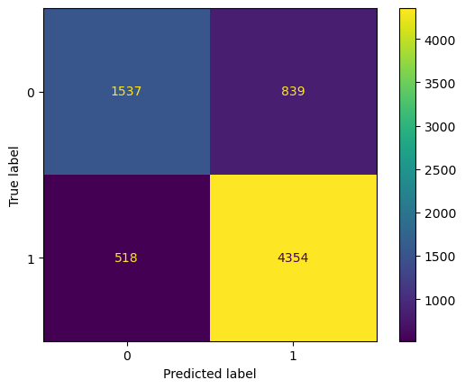

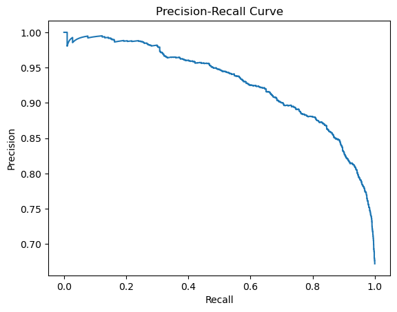

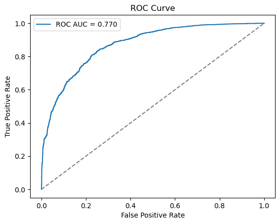

```python
from sklearn.metrics import confusion_matrix, ConfusionMatrixDisplay, precision_recall_curve, roc_curve
import matplotlib.pyplot as plt

# ... (Your code for model training remains the same)

# Confusion Matrix
y_pred = logreg_oob.predict(clf.transform(X_test))
cm = confusion_matrix(y_test, y_pred)
disp = ConfusionMatrixDisplay(confusion_matrix=cm)
disp.plot()
plt.show()

# Precision-Recall Curve
precision, recall, _ = precision_recall_curve(y_test, logreg_oob.predict_proba(clf.transform(X_test))[:, 1])  # Positive class probability
plt.plot(recall, precision)
plt.xlabel('Recall')
plt.ylabel('Precision')
plt.title('Precision-Recall Curve')
plt.show()

# ROC AUC Curve
fpr, tpr, _ = roc_curve(y_test, logreg_oob.predict_proba(clf.transform(X_test))[:, 1])  # Positive class probability
roc_auc = roc_auc_score(y_test, y_pred)
plt.plot(fpr, tpr, label=f'ROC AUC = {roc_auc:.3f}')
plt.plot([0, 1], [0, 1], linestyle='--', color='grey')  # Baseline
plt.xlabel('False Positive Rate')
plt.ylabel('True Positive Rate')
plt.title('ROC Curve')
plt.legend()
plt.show()
```

**Prompt:**

Let’s perform hyperparameter tuning to optimise the model performance. Start small by considering only a few combinations of hyperparameters.

```python
from sklearn.model_selection import GridSearchCV

param_grid = {
    'penalty': ['l1', 'l2'],
    'C': [0.01, 0.1, 1, 10],
    'solver': ['liblinear', 'saga']
}
```

```python
grid_search = GridSearchCV(estimator=logreg_oob, param_grid=param_grid, cv=5, n_jobs=-1)  # 5-fold Cross Validation
```

```python
grid_search.fit(clf.fit_transform(X_train), y_train)

best_model = grid_search.best_estimator_
print(grid_search.best_params_)  # Best hyperparameter combination found
print(grid_search.best_score_)  # Best performance metric achieved

# You can then use 'best_model' to predict on X_test for evaluation.
```

[output not shown]

[output cut: 218 more lines]

```
{'C': 1, 'penalty': 'l1', 'solver': 'liblinear'}
0.8141773025181097
```

```python
# Assuming 'grid_search' is your GridSearchCV object

y_pred = grid_search.best_estimator_.predict(clf.transform(X_test))

# ... (Use y_pred for evaluation metrics as before)

from sklearn.metrics import accuracy_score, precision_score, recall_score, f1_score, roc_auc_score
from sklearn.metrics import classification_report

accuracy = accuracy_score(y_test, y_pred)
precision = precision_score(y_test, y_pred)
recall = recall_score(y_test, y_pred)
f1 = f1_score(y_test, y_pred)
roc_auc = roc_auc_score(y_test, y_pred)

print("Accuracy:", accuracy)
print("Precision:", precision)
print("Recall:", recall)
print("F1 Score:", f1)
print("ROC AUC:", roc_auc)

print(classification_report(y_test, y_pred))
```

```
Accuracy: 0.8120860927152318
Precision: 0.8382806476484195
Recall: 0.8926518883415435
F1 Score: 0.8646123260437376
ROC AUC: 0.7697687051135327
              precision    recall  f1-score   support

           0       0.75      0.65      0.69      2376
           1       0.84      0.89      0.86      4872

    accuracy                           0.81      7248
   macro avg       0.79      0.77      0.78      7248
weighted avg       0.81      0.81      0.81      7248
```

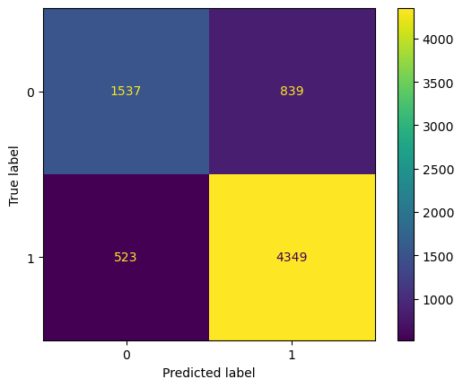

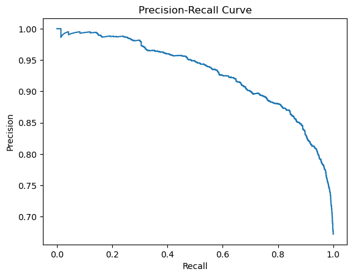

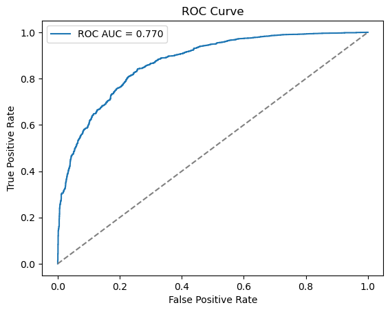

```python
from sklearn.metrics import confusion_matrix, ConfusionMatrixDisplay, precision_recall_curve, roc_curve
import matplotlib.pyplot as plt

# ... (Your code for model training remains the same)

# Confusion Matrix
y_pred = grid_search.best_estimator_.predict(clf.transform(X_test))
cm = confusion_matrix(y_test, y_pred)
disp = ConfusionMatrixDisplay(confusion_matrix=cm)
disp.plot()
plt.show()

# Precision-Recall Curve
precision, recall, _ = precision_recall_curve(y_test, grid_search.best_estimator_.predict_proba(clf.transform(X_test))[:, 1])  # Positive class probability
plt.plot(recall, precision)
plt.xlabel('Recall')
plt.ylabel('Precision')
plt.title('Precision-Recall Curve')
plt.show()

# ROC AUC Curve
fpr, tpr, _ = roc_curve(y_test, grid_search.best_estimator_.predict_proba(clf.transform(X_test))[:, 1])  # Positive class probability
roc_auc = roc_auc_score(y_test, y_pred)
plt.plot(fpr, tpr, label=f'ROC AUC = {roc_auc:.3f}')
plt.plot([0, 1], [0, 1], linestyle='--', color='grey')  # Baseline
plt.xlabel('False Positive Rate')
plt.ylabel('True Positive Rate')
plt.title('ROC Curve')
plt.legend()
plt.show()
```

**Prompt:**

Can you also use Hyperopt to perform hyperparameter tuning?

```python
from hyperopt import fmin, tpe, hp, Trials
from sklearn.model_selection import cross_val_score

def objective_function(params):
    # Unpack parameters
    penalty = params['penalty']
    C = params['C']
    solver = params['solver']

    # Create a new instance of your pipeline from the defined parameters
    model = Pipeline(steps=[
        ('preprocessor', preprocessor),  # Ensure your preprocessor is included here
        ('feature_poly', preprocessor_poly),
        ('classifier', LogisticRegression(penalty=penalty, C=C, solver=solver))
    ])

    # Evaluation with cross-validation
    scores = cross_val_score(model, X_train, y_train.values.ravel(), cv=5, scoring='roc_auc')  # Example metric
    mean_score = scores.mean()
    return 1 - mean_score  # Hyperopt minimizes, we want to maximize ROC AUC
```

```python
search_space = {
    'penalty': hp.choice('penalty', ['l1', 'l2']),
    'C': hp.uniform('C', 0.01, 10),
    'solver': hp.choice('solver', ['liblinear', 'saga'])
}
```

```python
trials = Trials()

best_params = fmin(
    fn=objective_function,
    space=search_space,
    algo=tpe.suggest,  # Tree-structured Parzen Estimator
    max_evals=50  # Number of parameter combinations to try
)

# Print the best combination found
print(best_params)
```

```
{'C': 9.017092153240982, 'penalty': 0, 'solver': 0}
```

```python
search_space = {
    'penalty': hp.choice('penalty', ['l1', 'l2']),
    'C': hp.uniform('C', 0.01, 10),
    'solver': hp.choice('solver', ['liblinear', 'saga'])
}
```

```python
best_params
```

```
{'C': 9.017092153240982, 'penalty': 0, 'solver': 0}
```

```python
best_params = {'C': 8.005716871935528, 'penalty': 0, 'solver': 0}

# Define mappings for penalty and solver
penalty_map = {0: 'l1', 1: 'l2'}
solver_map = {0: 'liblinear', 1: 'saga'}

# Map the indices to the actual values
best_params['penalty'] = penalty_map[best_params['penalty']]
best_params['solver'] = solver_map[best_params['solver']]

best_params
```

```
{'C': 8.005716871935528, 'penalty': 'l1', 'solver': 'liblinear'}
```

```python
# Assuming 'grid_search' is your GridSearchCV object

y_pred = logreg_oob.set_params(**best_params).predict(clf.transform(X_test))

# ... (Use y_pred for evaluation metrics as before)

from sklearn.metrics import accuracy_score, precision_score, recall_score, f1_score, roc_auc_score
from sklearn.metrics import classification_report

accuracy = accuracy_score(y_test, y_pred)
precision = precision_score(y_test, y_pred)
recall = recall_score(y_test, y_pred)
f1 = f1_score(y_test, y_pred)
roc_auc = roc_auc_score(y_test, y_pred)

print("Accuracy:", accuracy)
print("Precision:", precision)
print("Recall:", recall)
print("F1 Score:", f1)
print("ROC AUC:", roc_auc)

print(classification_report(y_test, y_pred))
```

```
Accuracy: 0.8127759381898455
Precision: 0.8384363566339302
Recall: 0.8936781609195402
F1 Score: 0.8651763537009438
ROC AUC: 0.770281841402531
              precision    recall  f1-score   support

           0       0.75      0.65      0.69      2376
           1       0.84      0.89      0.87      4872

    accuracy                           0.81      7248
   macro avg       0.79      0.77      0.78      7248
weighted avg       0.81      0.81      0.81      7248
```

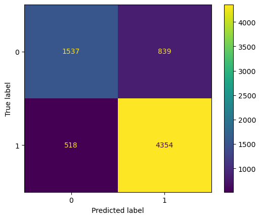

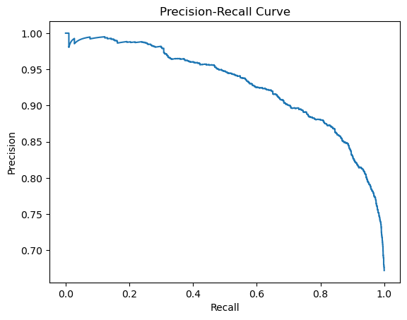

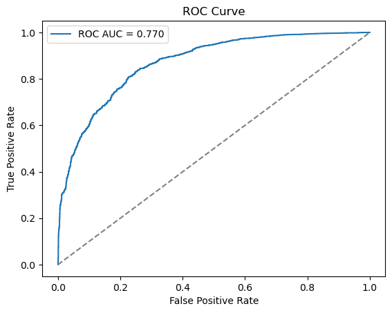

```python
# Confusion Matrix
y_pred = logreg_oob.set_params(**best_params).predict(clf.transform(X_test))
cm = confusion_matrix(y_test, y_pred)
disp = ConfusionMatrixDisplay(confusion_matrix=cm)
disp.plot()
plt.show()

# Precision-Recall Curve
precision, recall, _ = precision_recall_curve(y_test, logreg_oob.set_params(**best_params).predict_proba(clf.transform(X_test))[:, 1])  # Positive class probability
plt.plot(recall, precision)
plt.xlabel('Recall')
plt.ylabel('Precision')
plt.title('Precision-Recall Curve')
plt.show()

# ROC AUC Curve
fpr, tpr, _ = roc_curve(y_test, logreg_oob.set_params(**best_params).predict_proba(clf.transform(X_test))[:, 1])  # Positive class probability
roc_auc = roc_auc_score(y_test, y_pred)
plt.plot(fpr, tpr, label=f'ROC AUC = {roc_auc:.3f}')
plt.plot([0, 1], [0, 1], linestyle='--', color='grey')  # Baseline
plt.xlabel('False Positive Rate')
plt.ylabel('True Positive Rate')
plt.title('ROC Curve')
plt.legend()
plt.show()
```

**Prompt:**

I am done with the Logistic Regression model. Can we explore other models like XGBoost?

```python
import xgboost as xgb
from sklearn.model_selection import GridSearchCV, RandomizedSearchCV

# Example XGBoost model (adapt parameters as needed)
xgb_model = xgb.XGBClassifier(objective='binary:logistic', seed=42)

# Parameters to tune (refer to XGBoost documentation for more options)
param_grid = {
    'learning_rate': [0.01, 0.1],
    'max_depth': [3, 6, 10],
    'n_estimators': [50, 100, 200],
    'gamma': [0, 0.1, 0.2]
}

# Choose between GridSearchCV or RandomizedSearchCV
search = GridSearchCV(xgb_model, param_grid, cv=5, scoring='roc_auc', n_jobs=-1)

search.fit(clf.fit_transform(X_train).astype({'remainder__remainder__week_of_year': 'int8'}), y_train)

best_model = search.best_estimator_
y_pred = best_model.predict(clf.transform(X_test).astype({'remainder__remainder__week_of_year': 'int8'}))

# ... (Calculate evaluation metrics as before)
```

```python
accuracy = accuracy_score(y_test, y_pred)
precision = precision_score(y_test, y_pred)
recall = recall_score(y_test, y_pred)
f1 = f1_score(y_test, y_pred)
roc_auc = roc_auc_score(y_test, y_pred)

print("Accuracy:", accuracy)
print("Precision:", precision)
print("Recall:", recall)
print("F1 Score:", f1)
print("ROC AUC:", roc_auc)

print(classification_report(y_test, y_pred))
```

```
Accuracy: 0.8990066225165563
Precision: 0.9090909090909091
Recall: 0.9441707717569786
F1 Score: 0.9262988320579943
ROC AUC: 0.8752840390771426
              precision    recall  f1-score   support

           0       0.88      0.81      0.84      2376
           1       0.91      0.94      0.93      4872

    accuracy                           0.90      7248
   macro avg       0.89      0.88      0.88      7248
weighted avg       0.90      0.90      0.90      7248
```

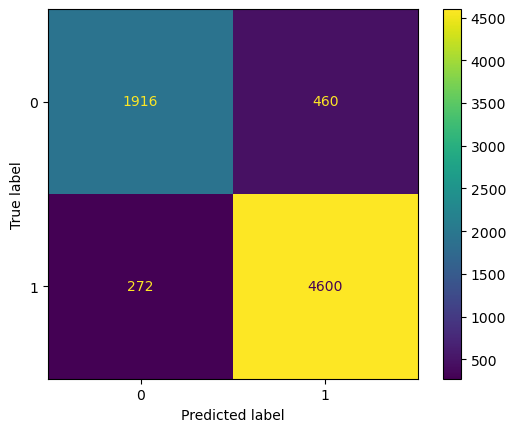

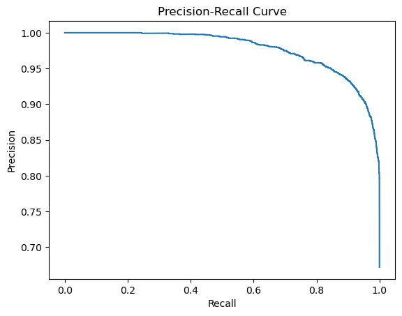

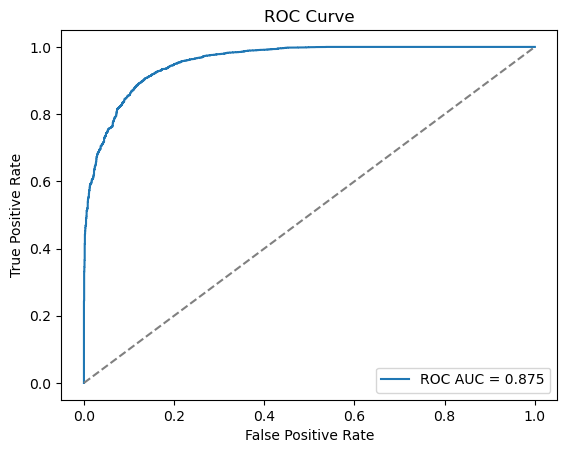

```python
# Confusion Matrix
y_pred = search.best_estimator_.predict(clf.transform(X_test).astype({'remainder__remainder__week_of_year': 'int8'}))
cm = confusion_matrix(y_test, y_pred)
disp = ConfusionMatrixDisplay(confusion_matrix=cm)
disp.plot()
plt.show()

# Precision-Recall Curve
precision, recall, _ = precision_recall_curve(y_test, search.best_estimator_.predict_proba(clf.transform(X_test).astype({'remainder__remainder__week_of_year': 'int8'}))[:, 1])  # Positive class probability
plt.plot(recall, precision)
plt.xlabel('Recall')
plt.ylabel('Precision')
plt.title('Precision-Recall Curve')
plt.show()

# ROC AUC Curve
fpr, tpr, _ = roc_curve(y_test, search.best_estimator_.predict_proba(clf.transform(X_test).astype({'remainder__remainder__week_of_year': 'int8'}))[:, 1])  # Positive class probability
roc_auc = roc_auc_score(y_test, y_pred)
plt.plot(fpr, tpr, label=f'ROC AUC = {roc_auc:.3f}')
plt.plot([0, 1], [0, 1], linestyle='--', color='grey')  # Baseline
plt.xlabel('False Positive Rate')
plt.ylabel('True Positive Rate')
plt.title('ROC Curve')
plt.legend()
plt.show()
```

**Prompt:**

I am done with the XGBoost model. Can we explore other models like SVC?

```python
from sklearn.svm import SVC
from sklearn.model_selection import GridSearchCV, RandomizedSearchCV

# Example SVC model (adjust parameters as needed)
svc_model = SVC(kernel='rbf', C=1, gamma='scale', probability=True)  # probability=True for ROC AUC

# Parameters to tune (refer to SVC documentation for other options)
param_grid = {
    'C': [0.1, 1, 10, 100],
    'gamma': ['scale', 0.01, 0.1],
    'kernel': ['rbf', 'linear'] # You can explore different kernels
}

# Choose between GridSearchCV or RandomizedSearchCV
search = RandomizedSearchCV(svc_model, param_grid, cv=5, scoring='roc_auc', n_jobs=-1)  # Or use RandomizedSearchCV

search.fit(clf.fit_transform(X_train), y_train)

best_model = search.best_estimator_
y_pred = best_model.predict(clf.transform(X_test))

# ... (Calculate evaluation metrics as before)
```

[output not shown]

[output cut: 76 more lines]

```python
accuracy = accuracy_score(y_test, y_pred)
precision = precision_score(y_test, y_pred)
recall = recall_score(y_test, y_pred)
f1 = f1_score(y_test, y_pred)
roc_auc = roc_auc_score(y_test, y_pred)

print("Accuracy:", accuracy)
print("Precision:", precision)
print("Recall:", recall)
print("F1 Score:", f1)
print("ROC AUC:", roc_auc)

print(classification_report(y_test, y_pred))
```

```
Accuracy: 0.8639624724061811
Precision: 0.8823297914207006
Recall: 0.9203612479474549
F1 Score: 0.9009443439823187
ROC AUC: 0.8343388731319765
              precision    recall  f1-score   support

           0       0.82      0.75      0.78      2376
           1       0.88      0.92      0.90      4872

    accuracy                           0.86      7248
   macro avg       0.85      0.83      0.84      7248
weighted avg       0.86      0.86      0.86      7248
```

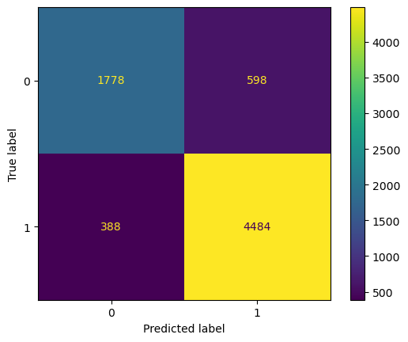

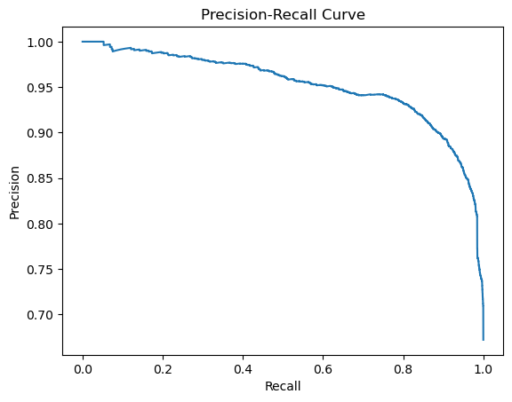

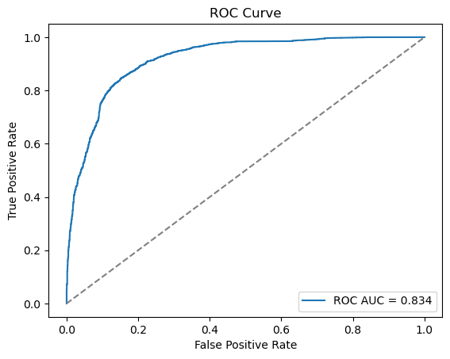

```python
# Confusion Matrix
y_pred = search.best_estimator_.predict(clf.transform(X_test).astype({'remainder__remainder__week_of_year': 'int8'}))
cm = confusion_matrix(y_test, y_pred)
disp = ConfusionMatrixDisplay(confusion_matrix=cm)
disp.plot()
plt.show()

# Precision-Recall Curve
precision, recall, _ = precision_recall_curve(y_test, search.best_estimator_.predict_proba(clf.transform(X_test).astype({'remainder__remainder__week_of_year': 'int8'}))[:, 1])  # Positive class probability
plt.plot(recall, precision)
plt.xlabel('Recall')
plt.ylabel('Precision')
plt.title('Precision-Recall Curve')
plt.show()

# ROC AUC Curve
fpr, tpr, _ = roc_curve(y_test, search.best_estimator_.predict_proba(clf.transform(X_test).astype({'remainder__remainder__week_of_year': 'int8'}))[:, 1])  # Positive class probability
roc_auc = roc_auc_score(y_test, y_pred)
plt.plot(fpr, tpr, label=f'ROC AUC = {roc_auc:.3f}')
plt.plot([0, 1], [0, 1], linestyle='--', color='grey')  # Baseline
plt.xlabel('False Positive Rate')
plt.ylabel('True Positive Rate')
plt.title('ROC Curve')
plt.legend()
plt.show()
```